# Введение в R

## Резюме

Особую роль в R играют векторы – числовые, символьное и логические. Из них строятся все остальные типы данных. Даже скаляры представляют собой лишь векторы единичной длины. Это приводит к тому, что все операции осуществляются над векторами в целом, а не над отдельными их элементами. В результате в R сравнительно редко используются циклы с перебором по элементам.

# Списки и таблицы

Векторы и матрицы состоят из данных одного типа. Чтобы сохранять наборы данных, относящихся к различным типам, в R существуют списки и таблицы.

## Списки

Список (`list`) напоминает вектор, но может содержать объекты разных типов. Создаётся список функцией `list`:

```r
lst <- list(n=1:3, s="test", b=c(T,F,F,F,T))
# или
n <- 1:3
s <- "test"
b <- c(T,F,F,F,T)
lst <- list(n,s,b) # состоит из копий векторов n,s,b
lst
```

```
## [[1]]
## [1] 1 2 3
##
## [[2]]
## [1] "test"
##
## [[3]]
## [1]  TRUE FALSE FALSE FALSE  TRUE
```

Структура созданного списка имеет вид:

```r
str(lst)
```

```
## List of 3
##  $ : int [1:3] 1 2 3
##  $ : chr "test"
##  $ : logi [1:5] TRUE FALSE FALSE FALSE TRUE
```

– список `lst` состоит из трёх элементов, каждый из которых является вектором: числовым, символьным и логическим соотвественно.

Элементы списков, так же как элементы векторов и матриц, могут иметь имена. Узнать или присвоить эти имена можно при помощи функции `names`:

```r
names(lst)
```

– в настоящий момент имена элементов `lst` не заданы.

Присвоим элементам списка `lst` имена `num`, `cha` и `log`:

```r
names(lst) <- c("num","cha","log")
```

и посмотрим, что получилось:

```r
str(lst)
```

```
## List of 3
##  $ num: int [1:3] 1 2 3
##  $ cha: chr "test"
##  $ log: logi [1:5] TRUE FALSE FALSE FALSE TRUE
```

Элементы списка можно выбрать одним из следующих способов:

1. с помощью квадратных скобок `[`,`]`. Полученный в результате объект в свою очередь будет являться списком, даже если длина его окажется единичной

```r
lst[1]  # или lst["num"]
```

```
## $num
## [1] 1 2 3
```

```r
class(lst[1])
```

```
## [1] "list"
```

2. с помощью двойных квадратных скобок `[[`,`]]`. Возвращенный объект будет того же типа, каким он был до включения в список

```r
lst[[1]] # или lst[["num"]]
```

```
## [1] 1 2 3
```

```r
class(lst[[1]])
```

```
## [1] "integer"
```

3. использовать имена элементов списка и знак доллара `$`:

```r
lst$num
```

```
## [1] 1 2 3
```

```r
class(lst$num)
```

```
## [1] "integer"
```

Удалять имена элементов можно следующим образом:

```r
names(lst) <- NULL
```

но мы пока делать этого не будем.

Добавить элемент в список можно так же, как и в вектор – при помощи функций `c()` или `append()`:

```r
v <- 5:10             # создадим числовой вектор
l1 <- c(lst,list(v))  # преобразуем его и добавим в список
str(l1)
```

```
## List of 4
##  $ num: int [1:3] 1 2 3
##  $ cha: chr "test"
##  $ log: logi [1:5] TRUE FALSE FALSE FALSE TRUE
##  $    : int [1:6] 5 6 7 8 9 10
```

Заметим, что если вектор не преобразовать при помощи `list()`, то к списку будет добавлен не одни элемент-вектор, а шесть элементов-чисел:

```r
l2 <- c(lst,v)
str(l2)
```

```
## List of 9
##  $ num: int [1:3] 1 2 3
##  $ cha: chr "test"
##  $ log: logi [1:5] TRUE FALSE FALSE FALSE TRUE
##  $    : int 5
##  $    : int 6
##  $    : int 7
##  $    : int 8
##  $    : int 9
##  $    : int 10
```

Функции `c` и `append`, помимо векторов, позволяют объединять и списки:

```r
l12 <- c(l1,l2)
```

Удаляются элементы списка так же, как элементы вектора:

```r
remove <- c(2,3)      # удалить 2-й и 3-й элементы
lst <- lst[-remove]
str(lst)
```

```
## List of 1
##  $ num: int [1:3] 1 2 3
```

Определим количество элементов в списке `lst`:

```r
length(lst)
```

```
## [1] 1
```

Обратите внимание, что функция `length` возвращает нам число элементов списка. В нашем случае такой элемент один. Другое дело, что сам этот элемент является числовым вектором. Чтобы найти длину этого последнего нужно применить двойные квадратные скобки

```r
length(lst[[1]])
```

```
## [1] 3
```

или преобразовать список в вектор при помощи `unlist()`:

```r
vec_from_lst <- unlist(lst)
class(vec_from_lst)
```

```
## [1] "integer"
```

```r
length(vec_from_lst)
```

```
## [1] 3
```

## Таблицы

Таблицы (data frames) хранят двумерные данные, но, в отличие от матриц, позволяют находится в разных колонках данным разных типов. По своему внутреннему устройству, таблица – это список колонок равной длины. Можно сказать и так: если вы когда-нибудь видели таблицу в Microsoft Excel, то вам уже знакомы таблицы в R.

Создаются таблицы с помощью функции `data.frame`:

```r
df1 <- data.frame(a=1:5,b=6:10,c=letters[1:5])
str(df1)
```

```
## 'data.frame':    5 obs. of  3 variables:
##  $ a: int  1 2 3 4 5
##  $ b: int  6 7 8 9 10
##  $ c: Factor w/ 5 levels "a","b","c","d",..: 1 2 3 4 5
```

Таблицы можно объединять по строкам:

```r
df2 <- data.frame(a=6:10,b=11:15,c=letters[6:10])
rbind(df1,df2)
```

```
##     a  b c
## 1   1  6 a
## 2   2  7 b
## 3   3  8 c
## 4   4  9 d
## 5   5 10 e
## 6   6 11 f
## 7   7 12 g
## 8   8 13 h
## 9   9 14 i
## 10 10 15 j
```

или по столбцам:

```r
df2 <- data.frame(c=6:10,d=11:15,e=letters[6:10])
cbind(df1,df2)
```

```
##   a  b c  c  d e
## 1 1  6 a  6 11 f
## 2 2  7 b  7 12 g
## 3 3  8 c  8 13 h
## 4 4  9 d  9 14 i
## 5 5 10 e 10 15 j
```

Ещё один способ объединения таблиц даёт в результате список:

```r
l3 <- c(df1,df2)
str(l3)
```

```
## List of 6
##  $ a: int [1:5] 1 2 3 4 5
##  $ b: int [1:5] 6 7 8 9 10
##  $ c: Factor w/ 5 levels "a","b","c","d",..: 1 2 3 4 5
##  $ c: int [1:5] 6 7 8 9 10
##  $ d: int [1:5] 11 12 13 14 15
##  $ e: Factor w/ 5 levels "f","g","h","i",..: 1 2 3 4 5
```

Если нужно объединить таблицы, имеющие общие колонки, то используется функция `merge`. Как правило, она используются для объединения таблиц с общими ключами:

```r
first <- data.frame(id=1:5, COL=LETTERS[1:5], col=letters[1:5])
secnd <- data.frame(id=1:5, col=letters[1:5])

# объединяем таблицы по колонке id
total <- merge(first,secnd,by="id")

# объединяем таблицы по колокам id и col
total <- merge(first,secnd,by=c("id","col"))
```

Размеры таблицы определяются следующим образом:

```r
length(df1) # длиной таблицы является длина списка, состоящего из колонок
```

```
## [1] 3
```

```r
ncol(df1)   # число колонок
```

```
## [1] 3
```

```r
nrow(df1)   # число строк
```

```
## [1] 5
```

Выбор элементов таблицы рассмотрим на примерах:

```r
df <- data.frame(a=1:5,b=6:10,c=letters[1:5])
df                # вся таблица
```

```
##   a  b c
## 1 1  6 a
## 2 2  7 b
## 3 3  8 c
## 4 4  9 d
## 5 5 10 e
```

```r
df[1,]            # 1-я строка
```

```
##   a b c
## 1 1 6 a
```

```r
df[,2]            # 2-ая колонка
```

```
## [1]  6  7  8  9 10
```

```r
df[4,3]           # элемент 4-й строки 3-й колонки
```

```
## [1] d
## Levels: a b c d e
```

```r
df[4,c(1,3)]      # элемент 4-й строки из 1-ой и 3-й колонок
```

```
##   a c
## 4 4 d
```

Иногда для выбора нужного фрагмента таблицы удобно использовать логические условия:

```r
df[df$c == 'd', ] # 4-я строка
```

```
##   a b c
## 4 4 9 d
```

```r
df[,df$c == 'a']  # 1-ая колонка
```

```
## [1] 1 2 3 4 5
```

```r
df[,df$c == 'd']  # Нет такой колонки!
```

```
## Error in `[.data.frame`(df, , df$c == "d"): undefined columns selected
```

Другой способ, позволяющий выделить фрагмент таблицы – использование функции `subset`.

Для работы с именами колонок, помимо функции `names`, существует отдельная функция:

```r
colnames(df)
```

```
## [1] "a" "b" "c"
```

Можно также задать имена строк таблицы. Делается это с помощью функции `rownames()`:

```r
rownames(df) <- LETTERS[1:nrow(df)]
```

Теперь выбирать элемент таблицы `df` можно так:

```r
df["A","b"] # df[1,2]
```

```
## [1] 6
```

```r
View(df)
```

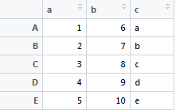

Представление таблицы df с помощью функции View в среде разработки RStudio

Большую таблицу отображать на экране нецелесообразно. Чтобы понять, как она устроена, достаточно рассмотреть её “голову” (`head`) или “хвост” (`tail`). Если данные в таблице упорядочены по времени, это позволит увидеть наиболее свежие или, наоборот, самые старые данные. Число выводимых строк таблицы регулируется параметром `n` и по умолчанию равно 6:

```r
df <- data.frame(col1=1:20, col2=letters[1:20])
head(df)
```

```
##   col1 col2
## 1    1    a
## 2    2    b
## 3    3    c
## 4    4    d
## 5    5    e
## 6    6    f
```

```r
tail(df, n=3)
```

```
##    col1 col2
## 18   18    r
## 19   19    s
## 20   20    t
```

Функции `head` и `tail` можно также применять для вывода частей векторов, матриц, списков и даже функций.

## Функции, применяемые к составным данным

Весьма распространённой причиной использования циклов является необходимость применить один и тот же набор операций (тело цикла) к элементам вектора, списка и т.п. Для решения этой задачи в R существует множество функций, большинство из которых относится к семейству `*apply` (`применить’). Благодаря этим функциям во многих случаях удаётся избежать использования циклов, что делает код на более компактным.

Мы рассмотрим три функции из семейства `*apply` (об остальных можно узнать в справке: `?lapply`) и дополняющую их функцию `do.call`.

### apply

`apply()` применяет функцию `fun` к строкам или столбцам матрицы и имеет вид:

```r
apply(матрица, размерность, fun)
```

Например:

```r
# Создадим матрицу M размера 4х4
M <- matrix(1:16,4,4)
M
```

```
##      [,1] [,2] [,3] [,4]
## [1,]    1    5    9   13
## [2,]    2    6   10   14
## [3,]    3    7   11   15
## [4,]    4    8   12   16
```

```r
# Найдём минимальные элементы среди строк M
apply(M,1,min)
```

```
## [1] 1 2 3 4
```

```r
# Найдём среднее арифметическое столбцов M
apply(M,2,mean)
```

```
## [1]  2.5  6.5 10.5 14.5
```

```r
# Проверим, являются ли столбцы M векторами
apply(M,2,is.vector)
```

```
## [1] TRUE TRUE TRUE TRUE
```

### lapply

`lapply()` (от ‘list apply’) применяет функцию `fun` к элементам списка или таблицы:

```r
lapply(список, fun)
```

Пример:

```r
x <- list(a = 1, b = 1:3, c = 10:50)
# Вычислим длину каждого элемента
lapply(x, length)
```

```
## $a
## [1] 1
##
## $b
## [1] 3
##
## $c
## [1] 41
```

```r
# ... и сумму его значений
lapply(x, sum)
```

```
## $a
## [1] 1
##
## $b
## [1] 6
##
## $c
## [1] 1230
```

Функции можно задавать самому:

```r
lapply(c(1,2,4), function(x) x^2)
```

```
## [[1]]
## [1] 1
##
## [[2]]
## [1] 4
##
## [[3]]
## [1] 16
```

Функция `fun` может зависеть и от нескольких аргументов:

```r
lapply(c(1,2,4), function(x,y)
                    x^2+y,
                        3 # значение, передаваемое y
       )
```

```
## [[1]]
## [1] 4
##
## [[2]]
## [1] 7
##
## [[3]]
## [1] 19
```

### sapply

Функция `sapply` работает аналогично `lapply`, но старается упростить тип результата. Например, если `lapply` возвращает список:

```r
li <- lapply(c(1,2,4), function(x) x^2)
str(li)
```

```
## List of 3
##  $ : num 1
##  $ : num 4
##  $ : num 16
```

то `sapply` удаётся получить вектор:

```r
ve <- sapply(c(1,2,4), function(x) x^2)
str(ve)
```

```
##  num [1:3] 1 4 16
```

или матрицу:

```r
x <- list(1:4, 5:8)
sapply(x, function(x) x^2)
```

```
##      [,1] [,2]
## [1,]    1   25
## [2,]    4   36
## [3,]    9   49
## [4,]   16   64
```

А вот как с помощью `sapply` преобразовать хранящиеся в таблице данные к числовому типу:

```r
# Преобразуем 1-ю и 3-ю колонки таблицы data:
data[, c(1,3)] <- sapply(data[, c(1,3)], as.numeric)
```

### do.call

Если `*apply` применяют заданную функцию к каждому элементу, выполняя таким образом множество вызовов функции, то `do.call` применяет функцию один раз ко всему списку аргументов:

```r
do.call(fun, список_аргументов)
```

Примеры:

```r
do.call(sum, list(1,2,4,1,2))
# Без do.call понадобилось бы избавится от списка:
# li <- list(1,2,4,1,2)
# sum(unlist(li))
```

```
## [1] 10
```

```r
A <- list(1:3,4:6,7:9)
do.call(rbind,A)
```

```
##      [,1] [,2] [,3]
## [1,]    1    2    3
## [2,]    4    5    6
## [3,]    7    8    9
```

## Преобразование из широкой таблицы в длинную и обратно

Источник: http://www.cookbook-r.com/Manipulating_data/Converting_data_between_wide_and_long_format/

Преобразование таблиц из широкой формы в длинную часто используется перед визуализацией данных в ggplot2.

Исходная таблица в широком форме – каждой переменной соответствует колонка:

```r
olddata_wide <- read.table(header=TRUE, text="
 subject sex control cond1 cond2
       1   M     7.9  12.3  10.7
       2   F     6.3  10.6  11.1
       3   F     9.5  13.1  13.8
       4   M    11.5  13.4  12.9
 ")
```

Та же таблица в длинной форме: “subject” и “sex” идентифицируют наблюдения, в колонке “condition” – названия измеряемых величин, в “measurement” – их значения.

```
##    subject sex condition measurement
## 1        1   M   control         7.9
## 2        2   F   control         6.3
## 3        3   F   control         9.5
## 4        4   M   control        11.5
## 5        1   M     cond1        12.3
## 6        2   F     cond1        10.6
## 7        3   F     cond1        13.1
## 8        4   M     cond1        13.4
## 9        1   M     cond2        10.7
## 10       2   F     cond2        11.1
## 11       3   F     cond2        13.8
## 12       4   M     cond2        12.9
```

Для перевода в длинную форму понадобятся пакет `reshape2` и функция `melt`.

Любой пакет устанавливается функцией `install.packages("имяПакета")` или с помощью меню *Tools/Install Packages…* RStudio.

```r
# install.packages("reshape2")
library(reshape2)

# Укажем id.vars: эти переменные останутся неизменными после преобразования
melt(olddata_wide, id.vars=c("subject", "sex"))
```

```
##    subject sex variable value
## 1        1   M  control   7.9
## 2        2   F  control   6.3
## 3        3   F  control   9.5
## 4        4   M  control  11.5
## 5        1   M    cond1  12.3
## 6        2   F    cond1  10.6
## 7        3   F    cond1  13.1
## 8        4   M    cond1  13.4
## 9        1   M    cond2  10.7
## 10       2   F    cond2  11.1
## 11       3   F    cond2  13.8
## 12       4   M    cond2  12.9
```

Осталось сменить названия колонок “variable” и “value” на “condition” и “measurement”. Это можно было сделать сразу:

```r
data_long <- melt(olddata_wide,
                  # ID переменные останутся неизменными
                  id.vars = c("subject", "sex"),
                  # Имена колонок, подлежащих преобразованию
                  measure.vars = c("control", "cond1", "cond2" ),
                  # новые имена колонок
                  variable.name = "condition",
                  value.name="measurement")
data_long
```

```
##    subject sex condition measurement
## 1        1   M   control         7.9
## 2        2   F   control         6.3
## 3        3   F   control         9.5
## 4        4   M   control        11.5
## 5        1   M     cond1        12.3
## 6        2   F     cond1        10.6
## 7        3   F     cond1        13.1
## 8        4   M     cond1        13.4
## 9        1   M     cond2        10.7
## 10       2   F     cond2        11.1
## 11       3   F     cond2        13.8
## 12       4   M     cond2        12.9
```

```r
data_wide <- dcast(data_long,
                   subject + sex ~ condition,
                   value.var = "measurement")
data_wide
```

```
##   subject sex control cond1 cond2
## 1       1   M     7.9  12.3  10.7
## 2       2   F     6.3  10.6  11.1
## 3       3   F     9.5  13.1  13.8
## 4       4   M    11.5  13.4  12.9
```

## Рецепты

### Добавление элемента в список

```r
# Добавим в список list элемент newobj и дадим ему имя name
list.new <- append(list, list(name=newobj))
# При этом имена элементов из списка list сохраняются
```

### Удаление элементов из списка

```r
# Удаление 3-го элемента списка myList
myList[[3]] <- NULL
# При удалении нескольких элементов,
# подход тот же, что и при удалении элементов вектора
```

### Преобразование списка списков в таблицу

```r
# Создаем список списков
listoflists = list(list(c1=1, c2='a', c3=3, c4=4),
                   list(c1=5, c2='b', c3=6, c4=7))
# Преобразуем список в матрицу, транспонируем ее
# и преобразуем полученный результат в таблицу
df = as.data.frame(t(sapply(listoflists, unlist)))
```

### Поиск строки в таблице

```r
# Создадим тестовую таблицу данных.
> mydata <- data.frame(name = c("Antony", "Bob", "Cecilia", "Jack", "Mary", "Tony"),
+                      col_a = c(0, 1, 0, 1, 2, 3),
+                      col_b = c(3, 0, 3, 3, 1, 0),
+                      stringsAsFactors=FALSE)
> mydata
     name col_a col_b
1  Antony     0     3
2     Bob     1     0
3 Cecilia     0     3
4    Jack     1     3
5    Mary     2     1
6    Tony     3     0

# Нужные нам строки - 1-ая и 6-ая
> grep('[t,T]ony', mydata$name)
[1] 1 6

> mydata[grep('[t,T]ony', mydata$name),]
    name col_a col_b
1 Antony     0     3
6   Tony     3     0
```

### Создание пустой таблицы с заданными именами колонок

```r
# Создадим пустую таблицу mydata с числовыми колонками First, Second
# и символьной колонкой Third:
mydata <- data.frame(First=numeric(0),
                     Second=numeric(0),
                     Third = character(0),
                     stringsAsFactors=FALSE)
str(mydata) # проверим:

## 'data.frame':    0 obs. of  3 variables:
##  $ First: num
##  $ Second: num
##  $ Third: chr
```

### Добавление в таблицу пустых колонок с заданными именами

```r
# Задана таблица с единственной колонкой
df <- data.frame(id=1)
# Имена других колонок заданы заранее
namevector <- c("col2","col3","col4")
# Добавляем эти пустые колонки в таблицу
df[,namevector] <- NA
print(df)

##  id col1 col2 col3
##1  1   NA   NA   NA

# Заметим, что names() воспользоваться нельзя, т.к. изначально
# df имеет всего одну колонку, которой нельзя дать три имени.
```

### Создать пустую таблицу заданного размера

```r
# Создадим таблицу: 2 строки x 5 столбцов
df <- data.frame(matrix(NA, nrow = 2, ncol = 5))
str(df)
```

```
## 'data.frame':    2 obs. of  5 variables:
##  $ X1: logi  NA NA
##  $ X2: logi  NA NA
##  $ X3: logi  NA NA
##  $ X4: logi  NA NA
##  $ X5: logi  NA NA
```

### Изменение кодировки таблицы

```r
# Используем функцию Encoding().

# Для одной колонки:
Encoding(table$colname) <- "UTF-8"

# Для всей таблицы:
for (i in 1:length(table))
  Encoding(table$[[i]]) <- "UTF-8"
```

### Сортировка строк таблицы по содержимому одной из колонок

```r
# Создаем тестовую таблицу
numPeople = 10
sex=sample(c("male","female"),numPeople,replace=T)
age = sample(14:102, numPeople, replace=T)
income = sample(20:150, numPeople, replace=T)
population = data.frame(sex=sex, age=age, income=income)
# Выводим ее содержимое
population
# sex age income
# 1  female  42     40
# 2  female  99     41
# 3    male  28     75
# 4  female  20     62
# 5  female  25    113
# 6    male  52     51
# 7    male  16    137
# 8    male  53     37
# 9    male  14     22
# 10   male  60     76

# Упорядочиваем строки таблицы по возрастанию значений из колонки age
population[order(population$age),]
# sex age income
# 9    male  14     22
# 7    male  16    137
# 4  female  20     62
# 5  female  25    113
# 3    male  28     75
# 1  female  42     40
# 6    male  52     51
# 8    male  53     37
# 10   male  60     76
# 2  female  99     41
```

### Запись таблицы в файл .csv без заголовков столбцов

```r
# Обычно верхний столбец в записанном csv-файле содержит заголовки строк.
# Если такой заголовок не нужен, делаем так:

write.table(my_data_frame, sep=",",  col.names=FALSE)

# Обратите внимание: используется write.table, а не write.csv.
```

### Преобразовать колонки таблицы в числовой тип данных

```r
# Преобразуем 1-ю и 3-ю колонки таблицы data:
data[, c(1,3)] <- sapply(data[, c(1,3)], as.numeric)
```

### Удалить пустые колонки таблицы

```r
# Создадим тестовую таблицу с двумя пустыми колонками:
dat <- data.frame(a=1:5, b=1:5, c=rep(NA,5), d=1:5, e=rep(NA,5))
# Удалим колонки, целиком состоящие из NA из таблицы dat:
dat <- dat[, !sapply(dat, function(x) all(is.na(x))), drop=F]
```

### Удалить строки с NA из таблицы

```r
df <- data.frame(first=letters[1:5],
                 second=c(1,2,NA,4,NA),
                 third=c(8,7,NA,5,4))
#   first second third
# 1     a      1     8
# 2     b      2     7
# 3     c     NA    NA
# 4     d      4     5
# 5     e     NA     4

# Удалить все строки с NA - вариант 1
na.omit(df)
# или, что то же самое, оставить только
# строки без NA
df[complete.cases(df),]
#   first second third
# 1     a      1     8
# 2     b      2     7
# 4     d      4     5

# Удалить строки с NA в заданном столбце
# В примере - в 3-ем
df[complete.cases(df[,3]),]
# first second third
# 1     a      1     8
# 2     b      2     7
# 4     d      4     5
# 5     e     NA     4
```

### Поменять местами строки и столбцы таблицы

```r
df <-  data.frame(A=1:3, B=letters[1:3], stringsAsFactors = T)
data.frame(t(df))
```

### Удалить из таблицы колонки с заданными именами

```r
# Создаем таблицу
df = data.frame(c1=1:4, c2=letters[1:4], c3=5:8)
# Удаляем колонку "с2"
df_new = df[ , -which(names(df) %in% c("c2"))]
```

## Резюме

Списки представляют собой одномерные наборы разнотипных данных. На их основе создаются таблицы (data frame), представляющие собой списки колонок. Как правило, данные, которые нам предстоит собирать, будут сохраняться именно в виде таблиц.

Функции семейства `*apply` позволяют применить один и тот же набор операций к элементам матрицы, списка, таблицы и т.п., что позволяет во многих случаях избежать использование циклов.

# Управление процессом вычислений

## Циклы

Циклы в R используются сравнительно редко. “Винить” в этом следует векторизацию вычислений. Тем не менее, иногда именно циклы являются наиболее простым путём решения задачи.

Синтаксис циклов R очень похож на синтаксис циклов C-подобных языков программирования. Циклы в R могут вкладываться друг друга в соответствии с обычными правилами вложения циклов.

### Цикл со счётчиком

Цикл со счётчиком записывается следующим образом:

```r
for (i in start:stop) {
  <тело цикла>
}
```

Его удобно применять, когда количество повторений команд, помещённых в тело цикла, известно заранее. Предположим, например, что в банк положена сумма в 1000 долларов сроком на 5 лет с процентной ставкой 12% годовых, и нужно узнать, сколько денег окажется на счету вкладчика по окончании срока вклада.

```r
sum0 <- 1000     # исходная сумма
rate <- .12      # процент
num_years <- 5   # срок хранения
sum <- sum0      # текущая сумма
for (i in 1:num_years) {
  sum <- sum + rate*sum0
  print(c(i,sum)) # выводим на печать номер года и накопленную сумму
}
```

```
## [1]    1 1120
## [1]    2 1240
## [1]    3 1360
## [1]    4 1480
## [1]    5 1600
```

Заметим что “эхо” внутри цикла не работает и для вывода промежуточных данных используется функция `print`.

Решение при помощи цикла – простое и прямолинейное, но не самое короткое. Немного подумав, можно прийти к формуле:

```r
sum0*(1+num_years*rate)
```

```
## [1] 1600
```

Оценим время, затраченное на заполнение при помощи цикла элементов динамического массива (вектора `x`):

```r
n <- 50000             # число элементов
x <- c()               # создадим пустой вектор
system.time(
  for (i in 1:n) {
    x <- c(x,i)        # дополним вектор x очередным элементом
  }
)
```

```
##   user system elapsed
##  5.348  0.072   5.426
```

Обратите внимание на то, как вкладывается цикл в функцию оценки времени `system.time`.

Аргумент `user` функции `system.time` возвращает процессорное время в секундах, затраченное текущим процессом (сеансом работы с R). `system` – это процессорное время, затраченное операционной системой на выполнение работ, связанных с текущим процессом (открытие файлов, операции ввода/вывода, запуск других процессов и т.п.). Наконец, `elapsed = user+system` содержит полное время работы скрипта.

Использованный нами способ инициализации вектора, очевидно, неэффективен. В первую очередь, желательно зарезервировать место под элементы вектора:

```r
x <- vector(length = n) # создадим вектор заданной длины
system.time(
  for (i in 1:n) {
    x[i] <- i
  }
)
```

```
##   user system elapsed
##  0.096  0.008   0.103
```

Экономия времени налицо. Однако лучший результат достигается при использовании векторизации:

```r
system.time(x <- 1:n)
```

```
##   user system elapsed
##      0      0       0
```

Такая ситуация типична для R: циклы работают медленнее, чем векторизованные функции.

Всё происходит так быстро, что `system.time` не успевает отследить изменения. Для более точной оценки времени выполнения скрипта используем пакет [tictoc](https://cran.fhcrc.org/web/packages/tictoc/):

```r
# install.packages("tictoc")
library(tictoc) # загрузим пакет tictoc
tic()           # засечём время
x <- 1:n
toc()           # остановим таймер и выведем результат
```

```
## 0.004 sec elapsed
```

### Цикл с предусловием

Цикл с предварительным условием используется тогда, когда число повторений тела цикла неизвестно, зато известно условие, которое должно быть выполнено в результате этих повторений.

Тело цикла выполняется до тех пор, пока истинно `логическое условие`:

```r
while (логическое_условие) {
 <тело цикла>
}
```

Вновь рассмотрим задачу о банковском вкладе. Только теперь процент будет не простой, а сложный, то есть будет добавляться к исходной сумме вклада. Определим, через сколько лет сумма, накапливаемая таким способом, превысит ту, что удалось скопить с помощью простого процента (`1600`) и сколько именно денег удасться скопить.

```r
sum0 <- 1000
rate <- .12
i <- 0
sum <- sum0
while (sum < 1600) {
 sum <- sum + rate*sum
 i <- i + 1
 print(c(i,sum))
}
```

```
## [1]    1 1120
## [1]    2.0 1254.4
## [1]    3.000 1404.928
## [1]    4.000 1573.519
## [1]    5.000 1762.342
```

Естественно, что и в этом случае можно было записать формулу:

```r
sum0*(1+rate)^num_years
```

```
## [1] 1762.342
```

Для преждевременного выхода из цикла используется команда `break`. После неё управление передаётся во внешний цикл, команде, следующей за циклом из которого мы вышли:

```r
for (i in 1:3) {
  for (j in 1:3) {
    if (j==2) break
    cat(sprintf('  loop: i=%d j=%d\n',i,j))
  }
  cat(sprintf('breake: i=%d j=%d\n',i,j))
}
```

```
##   loop: i=1 j=1
## breake: i=1 j=2
##   loop: i=2 j=1
## breake: i=2 j=2
##   loop: i=3 j=1
## breake: i=3 j=2
```

Команда `next` выполняет переход к следующей итерации цикла.

## Условные операторы

Скалярный условный оператор `if` или, проще говоря, обычный `if` записывается так:

```r
if (логическое_условие) {
  операторы выполняются
  если логическое_условие истинно
} else {
  операторы выполняются
  если логическое_условие ложно
}
```

Конструкции `else-if` в R нет.

Обратите внимание! Если в коде записано:

```r
if (condition == TRUE) x <- TRUE
else x <- FALSE
```

то R воспринимает первую строку как закончившуюся. Вторая строка начинается с `else`, который будет истолкован как самостоятельный оператор. Поскольку такого оператора не существует, будет выдано сообщение об ошибке

```r
##    Error: unexpected 'else' in " else"
```

Чтобы R интерпретировал `else` как часть предшествующего `if`’а, нужно указать ему при помощи фигурных скобок, что `if` ещё не закончился:

```r
if (condition == TRUE) {
  x <- TRUE
} else {x <- FALSE}
```

Есть в R и скалярный `switch`, но используется он редко.

Векторный условный оператор `ifelse` выполняет проверку условия сразу для всего вектора и возвращает логический индекс, в соответствии с которым выполняется то или иное действие:

```r
ifelse(логическое_условие, выполнить_если_ИСТИНА, выполнить_если_ЛОЖЬ)
```

Пример:

```r
x <- c(6:-4)
sqrt(x) # выдаёт предупреждение из-за наличия отрицательных аргументов
```

```
##  [1] 2.449490 2.236068 2.000000 1.732051 1.414214 1.000000 0.000000
##  [8]      NaN      NaN      NaN      NaN
```

`NaN` означает `Not-a-Number’, то есть результат не является числом.

Значения аргументов вначале необходимо отфильтровать, заменив отрицательные числа какими-нибудь другими значениями (в нашем случае удобно использовать `NA`), и лишь затем приступать к вычислению корня.

```r
x1 <- ifelse(x>=0,x,NA) # фильтр для данных
x1
```

```
##  [1]  6  5  4  3  2  1  0 NA NA NA NA
```

```r
sqrt(x1)
```

```
##  [1] 2.449490 2.236068 2.000000 1.732051 1.414214 1.000000 0.000000
##  [8]       NA       NA       NA       NA
```

Однако мы снова получим предупреждение в ситуации:

```r
ifelse(x>0,sqrt(x),NA)
```

```
## Warning in sqrt(x): созданы NaN
```

```
##  [1] 2.449490 2.236068 2.000000 1.732051 1.414214 1.000000       NA
##  [8]       NA       NA       NA       NA
```

– потому что, несмотря на условие, `sqrt()` выполняет операцию над исходным “нефильтрованным” вектором.

## Резюме

Циклы в R используются сравнительно редко: вместо них используется векторизация и функции семейства `*apply`, выполняющие групповые операции над элементами массивов, списков и таблиц. Синтаксис циклов R мало чем отличается от большинства С-подобных языков программирования.

Особенностью R является наличие векторного условного оператора `ifelse`.

# Базовая графика

Рассмотрим основы работы с базовой двумерной графикой R. “Базовой” она названа потому, что реализована в пакете `graphics`, который поставляется вместе с R и подключается автоматически.

Графические возможности R весьма богаты и их описанию посвящён ряд монографий. Так, в R существуют пакеты [lattice](https://cran.r-project.org/web/packages/lattice/) и [ggplot2](https://cran.r-project.org/web/packages/ggplot2/), возможности которых даже шире, чем у `graphics`, и которые используют другую идеологию построения графиков.

Графики в R выводятся в различные графические устройства: окна, если вывод осуществляется на экран, или файлы, если данные сохраняются на диске.

## Функции низкого и высокого уровней

Построим график синусоиды, координаты которой хранятся в векторах `x` и `y`:

```r
x <- seq(-pi,pi,.1)
y <- sin(x)
```

График можно составить из отдельных элементов:

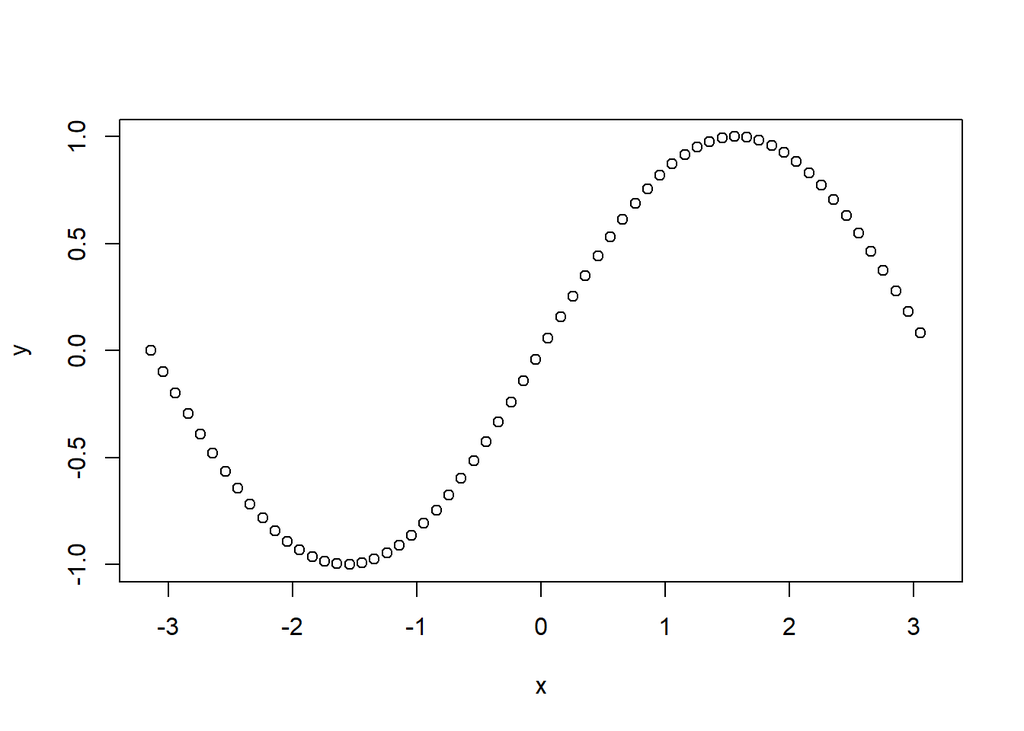

```r
plot.new() # пустое окно, готовое к добавлению графиков
plot.window(xlim = c(-pi,pi), ylim = c(-1,1))
points(x,y)
axis(1)
axis(2)
box()
title(xlab = "x")
title(ylab = "y")
```

Функции, реализующие тот или иной элемент графика, называются функциями низкого уровня или *низкоуровневыми*. В данном случае это:

- `plot.new`, которая создаёт новое графическое окно;
- `plot.window` – задаёт пределы изменения $x$ и $y$-координат на графике и другие графические параметры (те же, что и в функции `par()` – см. далее);
- `points` – строит график в виде точек;
- `axis` – добавляет на график оси координат: 1 – снизу, 2 – слева, 3 – сверху, 4 – справа;
- `box` – строит вокруг графика рамку;
- `title` – выводит пояснения к графикам. Например: параметры `xlab`, `ylab` задают обозначения осей координат, а `main` – заголовок графика.

Тот же график можно построить при помощи всего лишь одной функции:

```r
plot(x,y)
```

`plot` представляет собой пример функций высокого уровня, которые нацелены на реализацию наиболее распространённых видов графиков.

Как правило, в функциях высокого и низкого уровней используются одни и те же графические параметры. Вот, например, как можно оформить пояснения к графику при помощи параметров `main`, `xlab`, `ylab` функции `plot`:

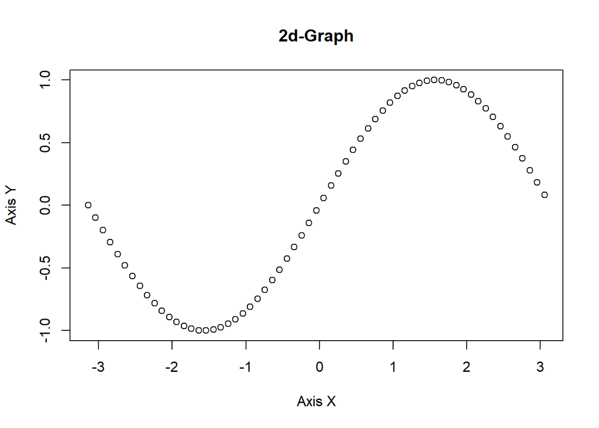

```r
plot(x, y,
     main = "2d-Graph",
     xlab = "Axis X",
     ylab = "Axis Y"
     )
```

По умолчанию, точки данных изображаются в виде незакрашенных кружков чёрного цвета. Символы для отображения точек (маркеры) настраиваются параметром `pch` (plot character), цвет – параметром `col`.

Пусть, например, точки данных будут отображаться красными “звёздочками”:

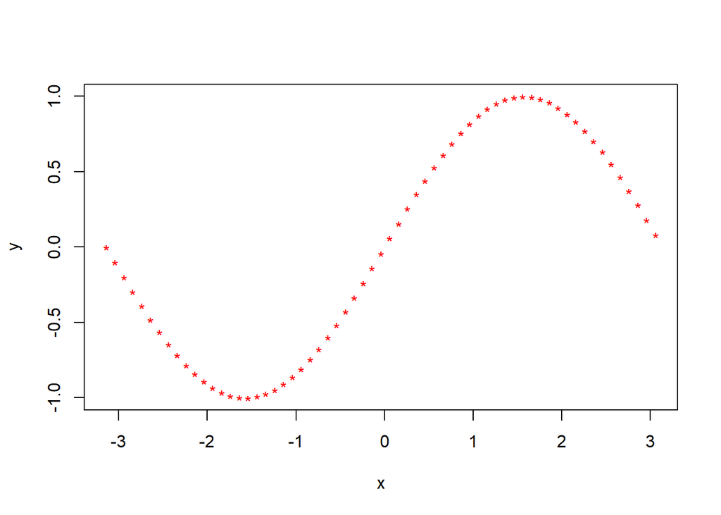

```r
plot(x,y,pch="*",col="red")
```

Маркеры можно задавать не только при помощи строк, но и по номерам. Первые двадцать видов маркеров приведены ниже

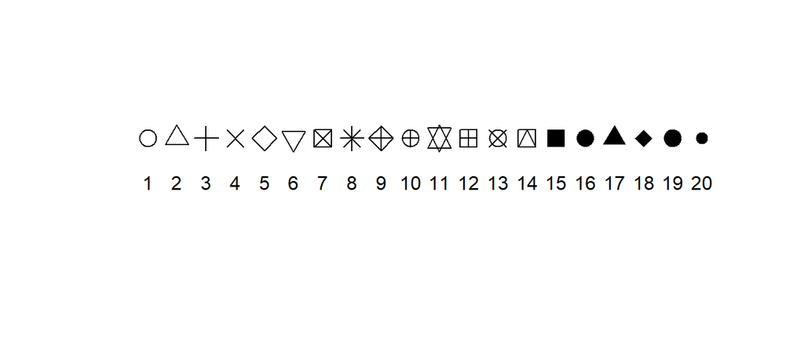

Маркеры

Помимо вида маркера в целом, можно настраивать отдельно цвет заполнения и цвет границы маркера.

Цвета можно задавать по номерам, названиям цветов на английском языке ([“red”, “green” и т. п.](https://www.datanovia.com/en/blog/awesome-list-of-657-r-color-names/)), а также шестнадцатиричным строкам вида `#RRGGBB` как в языке HTML

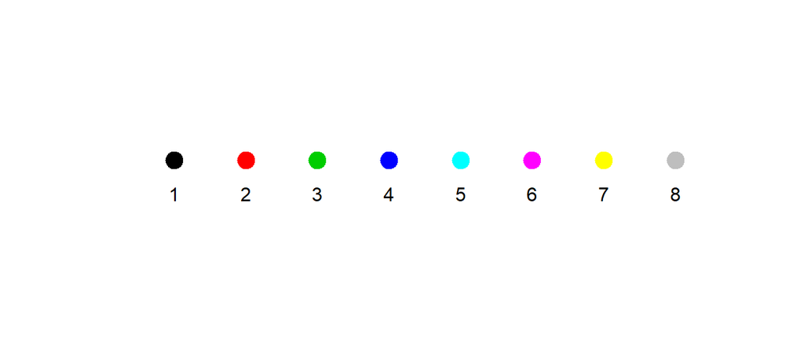

Цвета и их номера

Названия цветов, поддерживаемых R, возвращает функция `colors`. В настоящее время таких цветов 657.

`col2rgb` преобразует название цвета в его RGB-представление, а `rgb` вычисляет по этому представлению строку `#RRGGBB`.

Строить ли кривые на графике при помощи точек, линий или – и так и этак – определяет параметр `type`. Кроме того, для этой цели существуют специальные низкоуровневые функции, например, `lines`:

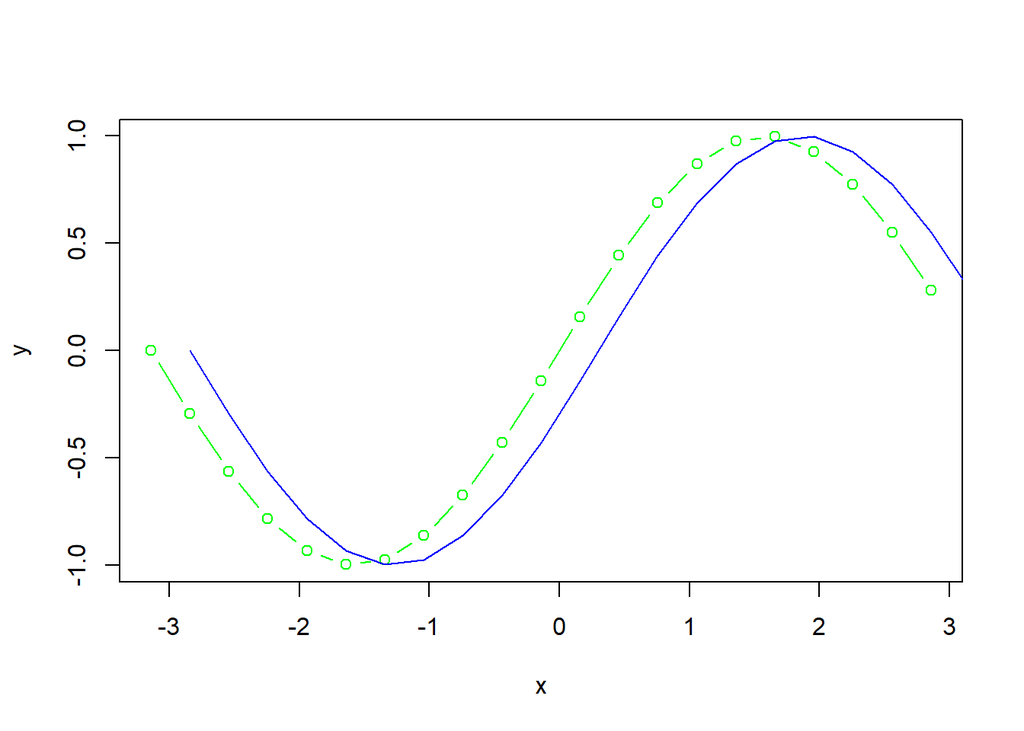

```r
x <- seq(-pi,pi,.3)
y <- sin(x)
plot(x,y,
     col="#00FF00",
     type="b"     # тип отображения кривой
                  #  "p" - точки (по умолчанию),
                  #  "l" - линия,
                  #  "b" - точки и линия (both))
    )
lines(x+.3, y, col="#0000FF")
```

Тип линии (сплошная, штриховая, пунктирная и т.п.) определяется параметром `lty` (`solid`, `dashed`, `dotted`… или по номерам). Параметр `lwd` задёт толщину линии в пунктах.

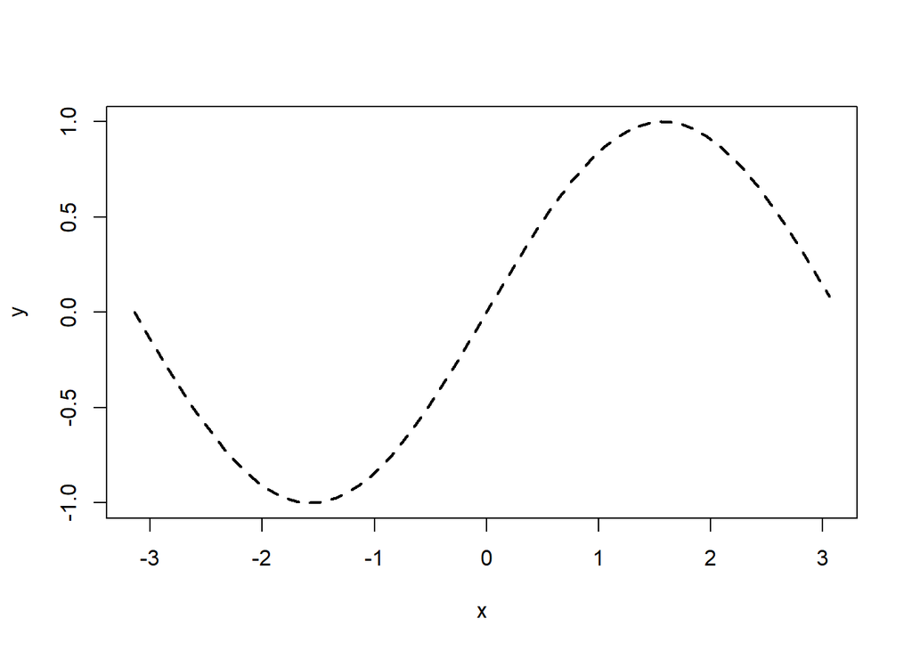

```r
x <- seq(-pi,pi,.1)
y <- sin(x)
plot(x,y,
     type="l",     # линия
     lty="dashed", # штриховая
     lwd=2         # толщиной 2 пт.
     )
```

Значение параметра `type="n"` позволяет создать пустой график.

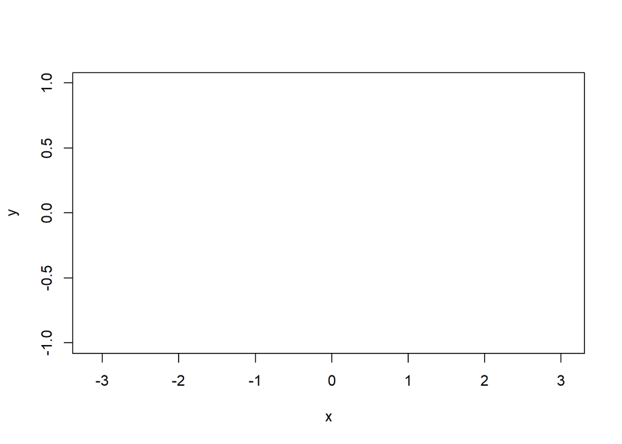

```r
plot(x, y, type="n")
```

## Глобальные и локальные параметры графиков

Для глобальной настройки параметров графиков используется функция `par`. Вызванная без аргументов, она позволяет узнать текущие значения всех графических параметров (в R версии 3.5.3 их 72).

Указав в качестве аргумента строку с именем графического параметра, получим значение одного этого параметра:

```r
par("col")
```

```
## [1] "black"
```

– по умолчанию, для рисования используется чёрный цвет.

Покажем, чем отличаются локальные параметры, которые задаются в конкретной функции построения графика (`plot`, `points`, `lines`) от глобальных параметров, устанавливаемых в `par`.

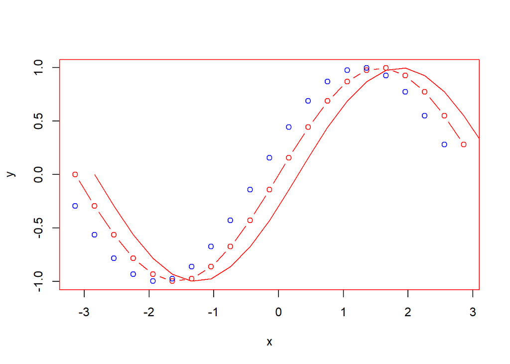

```r
x <- seq(-pi,pi,.3)
y <- sin(x)
par(col="red")
plot(x,y,type="b")
lines(x+.3, y)
points(x-.3, y, col="blue")
```

Функция `par` устанавливает единый для всех графиков цвет вывода кривых и осей координат (красный). Локальное значение параметра (синий цвет последнего графика) ожидаемо перекрывает действие глобального.

Действие настроек, сделанных в `par`, продолжается до конца сеанса работы с R. Чтобы восстановить предыдущие значения графических параметров, используют следующий приём:

```r
par()              # узнать текущие настройки
old_par <- par()   # сделать их копию
par(...)           # создать новые настройки
<plot>             # построить необходимые графики
par(old_par)       # восстановить прежние настройки
```

Список наиболее употребительных графических параметров приведен в таблице 1.

Наиболее употребительные графические параметры

| Обозначение | Значение |
| --- | --- |
| `main` | Заголовок графика |
| `xlab`, `ylab` | Подписи к осям $x$ и $y$ |
| `xlim`, `ylim` | Диапазон изменения данных по осям $x$ и $y$ |
| `pch` | Маркер, которым отображается точка данных |
| `cex` | Размер маркера |
| `col` | Цвет |
| `lty` | Тип линии (`solid`, `dashed`, `dotted`…) |
| `lwd` | Толщина линии |

## Легенда

Функция `legend` добавляет к текущему графику легенду – список пояснений, касающихся построенных на графике кривых. Рассмотрим построение легенды к графику на следующем примере:

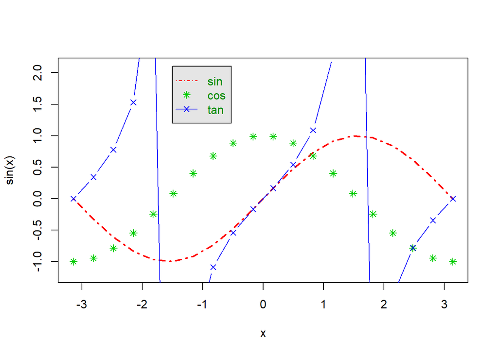

```r
# Строим три графика
x <- seq(-pi, pi, len=20)
plot(x, sin(x), type="l", ylim=c(-1.2, 2.1), col=2, lty=4, lwd=2)
points(x, cos(x), pch=8, col=3)
lines(x, tan(x), type="b", lty=1, pch=4, col=4)
# Строим легенду
legend(-1.5, 2.1,              # координаты левого верхнего угла
       c("sin", "cos", "tan"), # подписи
       col = c(2, 3, 4),       # цвет линии в легенде
       text.col = "green4",    # цвет подписи
       lty = c(4, -1, 1),      # тип линии в легенде
       pch = c(NA, 8, 4),      # маркер в легенде
       bg = "gray90"           # цвет фона в легенде
       )
```

Параметр `ylim` в `plot` нужен, чтобы качественно отобразить график тангенса. Иначе диапазон изменения $y$-координаты будет рассчитываться автоматически по значениям синуса и график тангенса окажется сплюснут.

Каждое из значений `-1` и `NA` в параметрах `lty` и `pch` легенды означает отсутствие соответствующего элемента: для `lty` – это отсутствие линий у графика, построенного точками; для `pch` – отсутствие маркеров у кривой, построенной c помощью линий.

## Комбинации графиков

Построим два графика в общих осях координат:

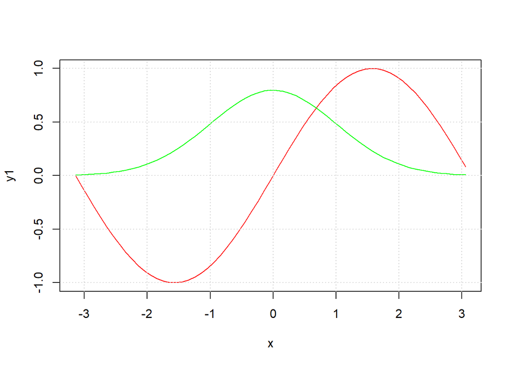

```r
x <- seq(-pi,pi,.1)
y1 <- sin(x)
y2 <- dnorm(x)
plot(x, y1, type="l", col="red")
lines(x, 2*y2, col="green")
grid()
```

Функции `lines` и `points`, в отличие от `plot`, не перерисовывают содержимое графического окна, а просто добавляют в него график.

Функция `grid` строит на графике сетку.

Построить несколько графиков в общем окне, но разных осях координат, можно при помощи параметра `mfrow` (или `mfcol`):

```
mfrow = c(число_строк,число_столбцов)
```

Расположение графиков в графическом окне можно представить в виде матрицы. Допустим, что в одной строке мы хотим разместить два графика. Выглядеть это будет так:

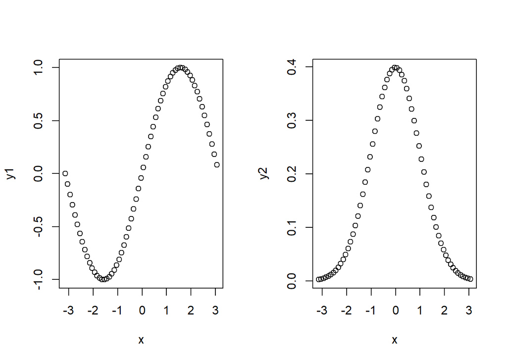

```r
par(mfrow=c(1,2))
plot(x,y1,mfrow=c(1,2))
plot(x,y2)
```

Заметим, что поскольку `mfrow` является глобальной настройкой, то все последующие графики в текущем сеансе работы будут отображаться по два в строке. Чтобы вернутся к обычному способу отображения графиков, нужно восстановить с помощью `par` настройки, принятые по умолчанию:

```r
par(mfrow=c(1,1))
```

Чтобы построить каждый график в отдельном окне, нужно перед очередным вызовом `plot` создавать новое графическое окно (устройство).

```r
# dev.new() - при первом вызове plot создаётся новое графическое устройство
plot(x,y1) # ... и дополнительно вызывать dev.new() не нужно
dev.new()  # Создать новое графическое устройство
plot(x,y2) # Вывести в него график
```

Кроме того:

- `dev.off()` – закрывает текущее графическое окно;
- `graphics.off()` – закрывает все графические окна в сессии.

## Графики функций

Для построения графиков функций вида $y=f(x)$ существует специальная функция:

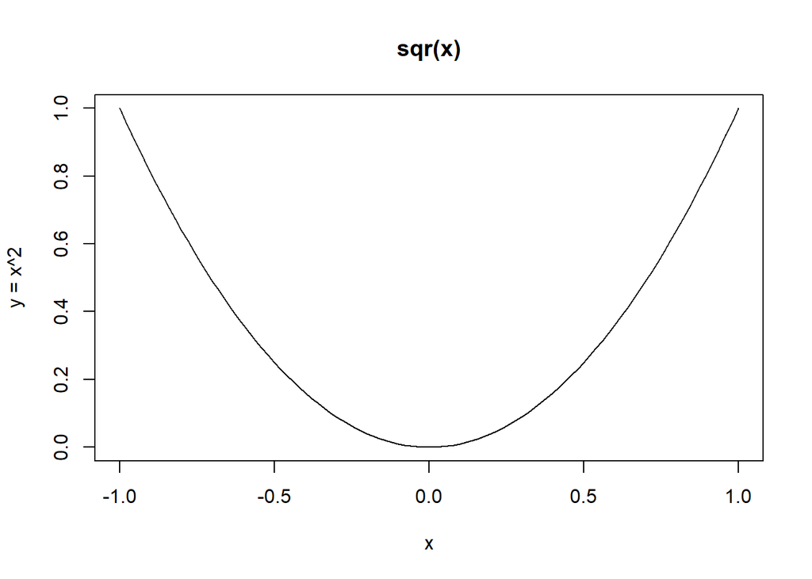

```r
curve(x^2, from=-1, to=1, main="sqr(x)", ylab="y = x^2")
```

## Экспорт в файлы

Справка по доступным графическим устройствам:

```r
?Devices
```

Узнать, в каких форматах можно сохранить график, позволяет также функция `capabilities`:

```r
capabilities()
```

```
##        jpeg         png        tiff       tcltk         X11        aqua
##        TRUE        TRUE        TRUE        TRUE       FALSE       FALSE
##    http/ftp     sockets      libxml        fifo      cledit       iconv
##        TRUE        TRUE        TRUE        TRUE       FALSE        TRUE
##         NLS     profmem       cairo         ICU long.double     libcurl
##        TRUE        TRUE        TRUE        TRUE        TRUE        TRUE
```

Она, в частности, возвращает имена функций, настраивающих параметры вывода в тот или иной графический формат.

Вот как происходит сохранение графика в файл формата PNG:

```r
# Описание устройства вывода
png("myfile.png", width=420, height=340, units="px")
# Вывод графика в устройство
plot(x,y1)
# Закрыть устройство
dev.off()
# Теперь можете посмотреть полученный файл
```

## Рецепты

### Несколько графиков на странице

Источник: http://rstudio-pubs-static.s3.amazonaws.com/2852_379274d7c5734f979e106dcf019ec46c.html

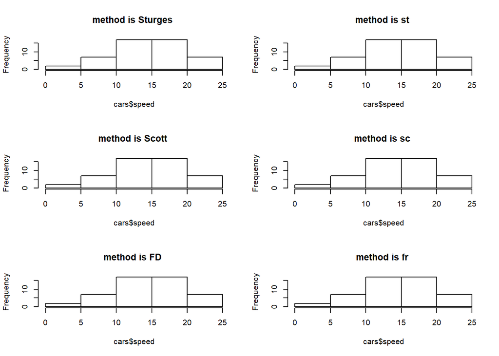

```r
par(mfrow = c(3, 2))  # 3 строки, 2 колонки
for (i in c("Sturges", "st", "Scott", "sc", "FD", "fr")) {
    hist(cars$speed, breaks = i, main = paste("method is", i, split = ""))
}
```

### Как найти координаты точки на графике

Для определения нужных строк и столбцов на графике можно воспользоваться функцией `locator`. При вызове этой функции R ждет, когда пользователь щелкнет на точке внутри изображения, и возвращает точные координаты этой точки. Так можно, например, расставлять текстовые пометки в заданных точках графика.

## Резюме

За пределами нашего рассказа остались мощнейшие пакеты [lattice](https://cran.r-project.org/web/packages/lattice/) и [ggplot2](https://cran.r-project.org/web/packages/ggplot2/). Последний мы рассмотрим позднее. По lattice есть книга:

- *Sarkar D.* Lattice: Multivariate Data Visualization with R. – Springer-Verlag New York, 2008.

# Функции

Функция – это фрагмент кода, предназначенный для решения какой-либо конкретной задачи. Мы уже знакомы с большим количеством готовых функций R и теперь научимся создавать функции сами, чтобы расширить возможности этого языка.

## Создание функций

Синтаксис функции имеет вид:

```r
function(список_аргументов) {
  тело функции
}
```

Например:

```r
function(x) {
  x^2
}
```

или, короче,

```r
function(x) x^2
```

У функции должно быть имя, чтобы её можно было вызвать:

```r
sqr <- function(x) x^2
sqr(2)
```

```
## [1] 4
```

Но можно использовать и анонимные функции:

```r
(function(x) x^2)(3)
```

```
## [1] 9
```

Обратите внимание, что присваивание имени функции выглядит так же, как присваивание значения переменной. И действительно, переменная `sqr` теперь относится к классу функций (“function”):

```r
class(sqr)
```

```
## [1] "function"
```

Вы можете проанализировать структуру функции, используя:

- `имя_функции` – без круглых скобок оно возвращает код функции;
- `body()` – возвращает код, помещённый в теле функции;
- `formals()` – возвращает список формальных параметров.

```r
sqr
```

```
## function(x) x^2
```

```r
body(sqr)
```

```
## x^2
```

```r
formals(sqr)
```

[output not shown]

По умолчанию, функция в R возвращает то значение, которое возвращается последней строкой её кода. Но для определённости лучше использовать `return()`:

```r
sqr <- function(x) {
  return(x^2)
}
```

Список аргументов функции может быть пуст и тогда после имени функции указываются лишь круглые скобки `()`. В списке можно задавать значения аргументов по умолчанию в виде `x = a`, а также формировать список аргументов переменной длины, добавляя `...` в конце списка.

Создадим функцию-обёртку над `plot`, то есть функцию, основу которой составляет `plot`, но с некоторыми “доработками” – в данном случае, с фиксированным значением параметра цвета (`col`):

```r
plot.red <- function(x, y, ...) {
  plot(x, y, col = "red", ...)
}
```

Вот как это работает:

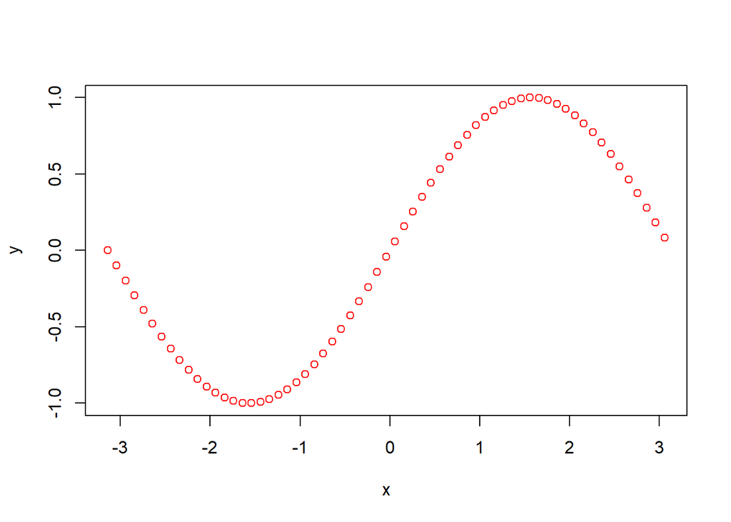

```r
x <- seq(-pi,pi,.1)
y <- sin(x)
plot.red(x,y)
```

Функции в R могут возвращать несколько объектов, относящихся к разным типам данных. Для этого такие объекты нужно предварительно поместить в список:

```r
sqr <- function(x) {
  val <- x^2
  txt <- "Squaring"
  ret <- list(value=val,text=txt)
  return(ret)
}
sqr(2)
```

```
## $value
## [1] 4
##
## $text
## [1] "Squaring"
```

## Локальные и глобальные переменные. Области видимости

Переменные, созданные внутри функции, являются локальными, то есть их значения доступны (видимы) только внутри данной функции или вложенных в неё функций. Соотвественно и функция “видит” переменные, заданные вне её пределов:

```r
a <- 5

foo <- function() {
  b <- 10  # локальная переменная foo
  print(a) # foo видит a
  print(b) # foo видит b
}

foo()
```

```
## [1] 5
## [1] 10
```

```r
print(b)   # b в основной программе не определена
```

[output not shown]

Глобальные переменные внутри функции можно задать при помощи оператора присваивания `<<-`:

```r
a <- 5
foo <- function () {
   b <<- 10
   # другой вариант:
   # assign("b", "new", envir = .GlobalEnv)
}
foo()
b  # теперь b видима из основной программы
```

```
## [1] 10
```

Локальность и глобальность считается по отношению к конкретному окружению. Так, в следующем примере функция `g()` является глобальной по отношению к `h()`:

```r
g <- function(x) {
  h <- function(x) {x-1}
  print(environment(h))
  print(h(x))
  return(x+1)
}
g(2)
```

```
## <environment: 0x0000000018481200>
## [1] 1
```

```
## [1] 3
```

```r
w <- 12
f <- function(y) {
  d <- 8
  w <- w + 1
  y <- y - 2
  print(w)
  h <- function() {
    return(d*(w+y))
  }
  return(h())
}

t <- 4
f(t)
```

```
## [1] 13
```

```
## [1] 120
```

```r
w
```

```
## [1] 12
```

```r
t
```

```
## [1] 4
```

Переменная `w` на верхнем уровне не изменилась, изменилась только локальная копия `w` внутри `f()`. Переменная `t` на верхнем уровне осталась неизменной, хотя изменился связанный с ней формальный аргумент `у`.

## Диагностические сообщения

Для вывода диагностических сообщений используются функции:

- `message` – выводит сообщение;
- `warning` – выводит сообщение об ошибке, не останавливая выполнения команд;
- `stop` – выводит сообщение об ошибке и останавливает выполнение.

## Функции в качестве аргументов

В R функцию можно передавать в качестве аргумента в другие функции.

Допустим, у вас есть функция `toPercent`, преобразующая вектор чисел – процентов – в вектор строк со знаком `'%'`. В ней используется округление, выполняемое с помощью функции `round`:

```r
toPercent <- function(x) {
  percent <- round(x * 100)
  paste(percent, "%", sep = "")
}

a <- c(0.15, 1.26, 0.98, 1.02)
toPercent(a)
```

```
## [1] "15%"  "126%" "98%"  "102%"
```

Вдруг, неизвестно по какой причине, вам понадобилось выполнить округление при помощи другой функции – `signif`. Эта функция позволяет указывать, после какого знака следует округлять число.

Что делать? Писать новую функцию `toPercent` не слишком разумно, так как она будет почти точной копией предыдущей. Вместо этого слегка изменим `toPercent`:

```r
toPercent <- function(x, FUN = round, ...) {
  percent <- FUN(x * 100, ...)
  paste(percent, "%", sep = "")
}
```

Если не указывать явно аргумент `FUN`, то новая функция будет работать так же, как прежняя – ведь по умолчанию используется всё тот же `round`. Покажем это:

```r
a <- c(0.15, 1.26, 0.98, 1.02)
toPercent(a)
```

```
## [1] "15%"  "126%" "98%"  "102%"
```

Вместо многоточия `'...'` можно указывать дополнительные аргументы, которые будут передаваться функции `FUN`. Например:

```r
toPercent(a, FUN = signif, digits = 3)
```

```
## [1] "15%"  "126%" "98%"  "102%"
```

Здесь:

- R присваивает код функции `signif` аргументу `FUN` и функция `FUN()` становится точной копией `signif()`;
- `toPercent` принимает аргумент `digits` (число знаков, после которых `signif` выполняет округление) и передает его в `FUN()`.

Обратите внимание, что при передаче функции в качестве аргумента используется только имя функции, но не скобки – `signif`, а не `signif()`. Последний вариант R трактует как вызов функции, к тому же ошибочный из-за отсутствия аргументов.

Функция может быть неявным аргументом другой функции. Так, если в вызове функции `g()`

```r
g <- function(x, FUN = NULL) {
  if (missing(FUN))
    FUN <- function(x) x^2
  FUN(x)
}
```

используется только первый аргумент `x`, без которого никак не обойтись, то “скрытая” функция `FUN` возводит значение `x` в квадрат

```r
g(2)
```

```
## [1] 4
```

`missing` проверяет, не пропущен ли аргумент при вызове функции и, если это так, то запускает `FUN`.

Функцию `FUN` можно задать явно. Например, в виде анонимной функции:

```r
g(2, FUN = function(x) x^3)
```

```
## [1] 8
```

## Функциональное программирование

По сути, R является языком функционального программирования. Поэтому практически всё в нём делается при помощи функций. Например, элементы векторов выбираются при помощи функции-квадратной скобки:

```r
x <- c(1,2,3)
x[1]
```

```
## [1] 1
```

Такая форма записи привычна, но функцию-квадратную скобку можно переписать и в более “функциональном” виде:

```r
`[`(x,1)
```

```
## [1] 1
```

За следующей записью:

```r
`+`(1,`*`(2,3))
```

кроется обычное

```r
1+2*3
```

а операцию присваивания можно выполнить и так:

```r
assign("a",1)
a
```

```
## [1] 1
```

Создадим и мы какой-нибудь оператор. Так, в R нет готового оператора `+=`. Ликвидируем этот пробел:

```r
`%+=%` <- function(o1,o2) eval.parent(substitute(o1 <- o1 + o2))

x <- 1
x %+=% 2
x
```

```
## [1] 3
```

## Рецепты

### Оператор `+=`

Готового оператора `+=` в R нет, но его можно создать:

```r
`%+=%` = function(o1,o2) eval.parent(substitute(o1 <- o1 + o2))
x <- 1
x %+=% 2
```

### Глобальные переменные в функции

Оператор `<<-` внутри функции позволяет присвоить значение одноименной глобальной переменной:

```r
a <- "old"
test <- function () {
   a <<- "new"
   # другой вариант:
   # assign("a", "new", envir = .GlobalEnv)
}
test()
a
 [1] "new"
```

### Сохранение результатов работы функции в текстовом файле

Если результатом выполнения функции является вектор строк, то проблема решается функцией `writeLines()`. А если это нечто более хитрое? Тогда перенаправим вывод нашей функции с экрана (`stdout`) в файл:

```r
sink("myfile.txt") # перенаправим вывод из stdout в файл myfile.txt
my.func()          # запустим функцию, которая что-то выводит
sink()             # направим вывод назад в stdout
```

```r
# Вариант 1
is.empty <- function(x) {
    return(length(x)==0)
}
# Вариант 2
is.empty <- function(x) {
    return(identical(x, numeric(0)))
}
```

## Резюме

В R можно присваивать функции как значения переменных, передавать их в виде аргументов в другие функции, хранить функции в списках, создавать функции внутри функций и даже возвращать в качестве результата выполнения функции. Подробности можно найти во второй части книги Хэдли Уикэма:

- *Wickam H.* Advanced R. – CRC Press, 2015.

# Факторы и даты

Помимо количественных данных, нам будут встречаться данные качественные, которые нельзя представить в виде чисел. Для таких данных в R есть специальный тип данных – факторы. Кроме того, нам предстоит научиться работать с датами, поскольку многие данные привязаны к конкретным моментам времени.

## Категориальные данные

Данные, которые мы рассматривали до сих пор – числовые, строковые и логические – так или иначе можно представить при помощи “обычных” чисел. Но есть данные, с которыми так поступить не получится.

Рассмотрим, например, список товаров в магазине. Число наименований товаров (категорий) всегда ограничено. При этом каждый товар относится только к одной категории. Мы может отличить `"йогурт"` от `"велосипед"`, может определить количество йогуртов и велосипедов в нашем магазине. Мы даже можем упорядочить наименования товаров по алфавиту. Но нет смысла складывать йогурты и велосипеды. И даже если каждой категории товара присвоить уникальное число, то складывать такие числа всё равно бессмысленно.

Итак, существуют данные, которые обычно представляют собой строковые значения из ограниченного набора категорий (названия городов, ФИО сотрудников, марки автомобилей и т.п.) и для которых нельзя ввести алгебраические операции. Такие данные называются категориальными данными или *факторами*.

Но если данные представляются в виде строк, то может быть стоит и обойтись строками, не вводя нового типа данных? Посмотрим, какие преимущества даёт нам использование факторов.

Пусть у нас есть три вида фруктов и мы хотим подсчитать количество фруктов каждого вида и построить график.

```r
fruits <- c("apple", "orange", "orange", "banana", "apple", "orange")
is.character(fruits)
```

```
## [1] TRUE
```

```r
is.vector(fruits)
```

```
## [1] TRUE
```

Пока всё идёт хорошо. Но если мы захотим узнать количество фруктов одного вида, то нам придётся считать количество вхождений строки с наименованием этого вида фруктов в вектор `fruits`. Сделать это несложно, но всё же… И если понадобится построить график, например столбчатую диаграмму “вид фруктов-количество”, то нам также придётся повозится.

А что факторы? Для начала построим из вектора `fruits` одноимённый фактор:

```r
fruits <- as.factor(fruits)
```

Теперь это больше не строковый вектор – это фактор:

```r
is.character(fruits)
```

```
## [1] FALSE
```

```r
is.vector(fruits)
```

```
## [1] FALSE
```

```r
is.factor(fruits)
```

```
## [1] TRUE
```

Создавать факторы “с нуля” можно функцией `factor`.

У нас есть три категории фруктов:

```r
levels(fruits)
```

```
## [1] "apple"  "banana" "orange"
```

Функция `levels` позволяет как узнать, так и установить число категорий или *уровней* данного фактора. Сделать это можно и при создании фактора, управляя параметром `levels` в `factor()`. Есть в этой функции и возможность упорядочить категории (`ordered`), а также ввести для них специальные метки (`labels`).

“Всё это чудесно”, – скажет нетерпеливый читатель, “но как насчёт решения задачи?” А она уже решена.

Вот количество фруктов каждого вида:

```r
table(fruits)
```

```
## fruits
##  apple banana orange
##      2      1      3
```

А вот и диаграмма:

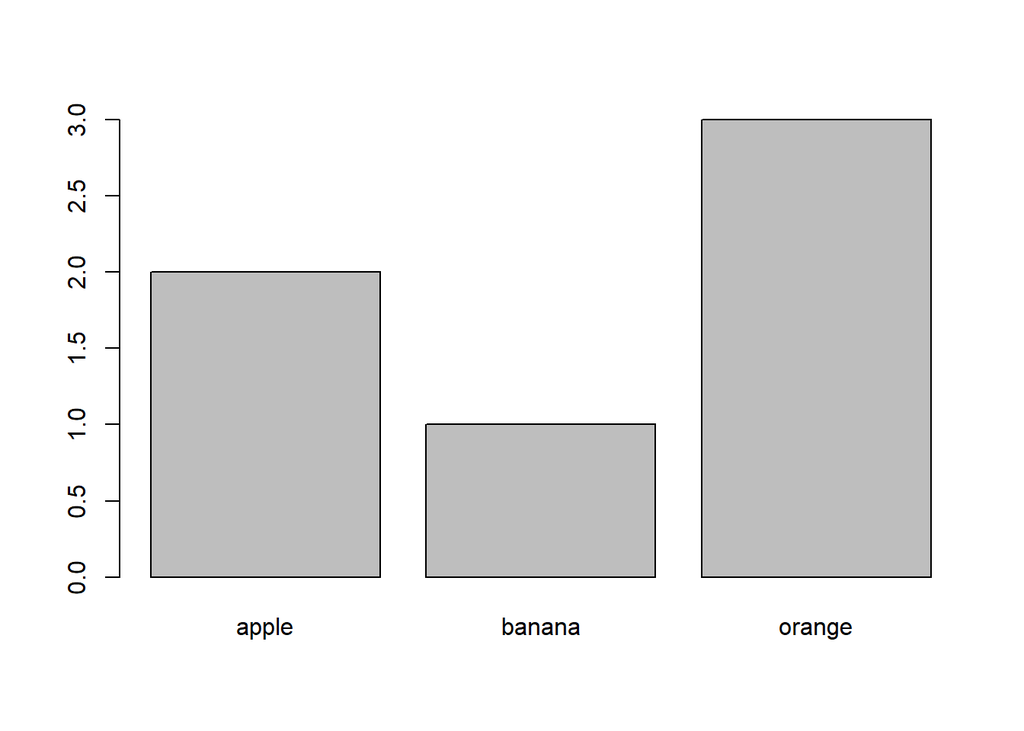

```r
plot(fruits)
```

Функция `which.max` позволяет определить уровень, встречающийся чаще всего:

```r
which.max(table(fruits))
```

```
## orange
##      3
```

## Дата и время

Работать с датами… непривычно. Даты нельзя складывать, но их можно вычитать, отвечая на вопрос: “Через сколько дней (часов, минут,…) после одного события произошло другое событие?”. При этом стоит учитывать возможные различия в часовых поясах. К датам можно добавлять и вычитать из них целые числа. Даты могут быть представлены в разных форматах… В общем, для работы с датами существует специальный тип данных – `Date`.

Создадим переменную типа `Date` при помощи функции `as.Date`, указав в качестве даты День космонавтики:

```r
cd <- as.Date("1961-04-12")
str(cd)
```

```
##  Date[1:1], format: "1961-04-12"
```

Какой день недели это был?

```r
weekdays(cd)
```

```
## [1] "среда"
```

Какой месяц?

```r
months(cd)
```

```
## [1] "Апрель"
```

А какой квартал года?

```r
quarters(cd)
```

```
## [1] "Q2"
```

Какая дата наступила через 7 дней?

```r
cd + 7
```

```
## [1] "1961-04-19"
```

Сколько дней оставалось до старта Германа Титова?

```r
as.Date("1961-08-6") - cd
```

```
## Time difference of 116 days
```

Функция `Sys.Date` возвращает текущую дату, а функция `Sys.time` – текущие дату и время.

```r
Sys.Date()
```

```
## [1] "2020-03-20"
```

```r
Sys.time()
```

```
## [1] "2020-03-20 14:15:27 EET"
```

`Sys.timezone()` возвращает часовой пояс, установленный в локальных настройках операционной системы (локали).

По умолчанию, число, месяц и год разделяются в строке даты символами `'-'`, иначе выражение не будет истолковано как дата. Формой представления даты можно управлять при помощи параметра `format`. Виды форматов даты и времени приведены в табл. 1 и 2.

Форматы представления даты.

| Формат | Описание |
| --- | --- |
| `%y` | Год без указания столетия |
| `%Y` | Год с указанием столетия |
| `%m` | Месяц в виде числа (от 01 до 12) |
| `%b` | Сокращённое название месяца, в соответствии с текущей локалью |
| `%B` | Полное название месяца в текущей локали |
| `%d` | День месяца (от 1 до 31) |
| `%a` | Сокращённое название дня недели, в соответствии с текущей локалью |
| `%A` | Полное название дня недели в текущей локали |
| `%w` | День недели в виде числа (от 0 до 6, где Sunday соотвествует 0) |

Форматы представления времени.

| Формат | Описание |
| --- | --- |
| `%I` | Часы (от 01 до 12) |
| `%H` | Часы (от 00 до 23) |
| `%M` | Минуты (от 00 до 59) |
| `%S` | Секунды (от 00 до 61) |
| `%p` | индикатор AM/PM |

Пусть число, месяц и год в исходных данных разделены пробелами:

```r
as.Date("12 4 1961", format="%d %m %Y")
```

```
## [1] "1961-04-12"
```

Если бы мы не указали нужный формат, то получили бы сообщение об ошибке:

```r
as.Date("12 4 1961")
```

```
## Error in charToDate(x): character string is not in a standard unambiguous format
```

Добавим к дате время запуска космического корабля “Восток-1” – 9 ч. 7 мин. по Московскому времени:

```r
# Запишем строку с датой и временем
cd_datetime <- "12 Апрель 1961 09:07:00"
# Зададим формат представления даты
cd_format <- "%d %B %Y %H:%M:%S"
# Воспользуемся функцией as.POSIXct, которая похожа на as.Date,
# но позволяет дополнительно задавать часовой пояс tz (time zone)
cd <- as.POSIXct(cd_datetime, format = cd_format, tz = "MSD")
cd
```

```
## [1] "1961-04-12 09:07:00 GMT"
```

Сменим формат представления даты на `Число/Месяц/Год`, для чего используем функцию `format`:

```r
format(cd, "%d/%m/%y")
```

```
## [1] "12/04/61"
```

А теперь вернёмся к `cd_format`:

```r
format(cd, cd_format)
```

```
## [1] "12 Апрель 1961 09:07:00"
```

Иногда может понадобится извлечь из даты, какой-то определённый элемент, например, минуты. В этом случае дату необходимо вначале преобразовать в тип данных `POSIXlt`, а затем извлечь из неё минуты (`min`):

```r
# преобразуем дату к типу POSIXlt
cd <- as.POSIXlt(cd)
str(cd)
```

```
##  POSIXlt[1:1], format: "1961-04-12 09:07:00"
```

```r
# и извлечём из неё минуты
cd$min
```

```
## [1] 7
```

## Рецепты

### Преобразование фактора в numeric

```r
f <- factor(sample(runif(5), 20, replace = TRUE))
(numeric_f <- as.numeric(levels(f)[f]))
```

```
##  [1] 0.78520977 0.51601810 0.84754525 0.84754525 0.51601810 0.30780229
##  [7] 0.06931988 0.84754525 0.06931988 0.30780229 0.51601810 0.78520977
## [13] 0.30780229 0.78520977 0.51601810 0.78520977 0.51601810 0.84754525
## [19] 0.06931988 0.51601810
```

### Как найти наиболее часто встречающийся уровень фактора

```r
y <- iris[c(-1,-150),5]
# table() покажет уровни фактора и их частоту
table(y)
y
    setosa versicolor  virginica
        49         50         49

# which.max() определить уровень, встречающийся чаще всего
# names() выведет имя этого уровня
names( which.max(table(y)) )
[1] "versicolor"
```

### Преобразовать год и номер дня в календарную дату

```r
as.Date("2019-32", format = "%Y-%j")
```

```
## [1] "2019-02-01"
```

## Резюме

Категориальные данные – это данные, значения которых делятся на категории. Такие данные отображают качественную информации об объекте, к которой не применимы арифметические операции. Для хранения категориальных данных в R существует специальный тип данных – факторы.

R позволяет манипулировать датами, представленными в разных форматах, с учётом часовых поясов. Для работы с датами существуют типы данных `Date`, `POSIXct` и `POSIXlt`.

# Ввод и вывод данных. Работа с файлами

Разнообразные операции ввода/вывода в R реализуются через единый механизм, называемыей соединением (connection). Соединение создается вызовом `file()`, `url()` или другой функции R. Соединение закрывается вызовом `close()`.

Перед тем как приступить к чтению или к записи данных, пользователь должен указать имя файла с которым ему предстоит работать. По умолчанию, поиск файла происходит в текущем рабочем каталоге пользователя.

Узнать текущий рабочий каталог можно с помощью функции `getwd` (*get working directory* – ‘узнать рабочий каталог’):

```r
getwd()
```

```
## [1] "D:/интеллектуальный_анализ_данных_2020/tutorial"
```

а установить – при помощи `setwd`:

```r
setwd("/path/to/dir")    # слэши '/' - как в Linux
setwd("\\path\\to\\dir") # или так
```

В начале рассмотрим функции R для записи данных. С их помощью мы создадим файлы, которые затем будем считывать.

## Запись данных в стандартное устройство вывода

По умолчанию, стандартным устройством вывода является консоль. Мы уже знакомы с одной из функций, которая выводит данные в консоль – это функция `print`. Но сейчас речь пойдёт о функции `cat`, обладающей гораздо большими возможностями.

По умолчанию, `cat` выводит данные в консоль:

```r
cat("Hello,\n", "world!\n")
```

Этот код можно улучшить, поскольку `cat` позволяет указать символ-разделитель строк в параметре `sep`:

```r
cat("Hello,", "world!", sep="\n")
```

Вот что получится в результате:

```
## Hello,
## world!
```

Кроме того, `cat` может выводить данные в файл, имя которого указывается в качестве значения параметра `file`.

```r
cat("Hello,", "world!", sep="\n", file="hello.txt")
```

В этом случае данные выводятся в файл `hello.txt`, расположенный в рабочем каталоге.

Направление вывода данных можно изменить при помощи функции `sink`. Например, перенаправим вывод из консоли в файл, а затем снова вернём его в консоль:

```r
sink("hello.txt")               # Перенаправляем вывод в файл hello.txt
cat("Hello,","world!",sep="\n") # Выводим данные в новую "консоль"
sink()                          # Возвращаем вывод в обычную консоль
```

## Запись в текстовые файлы

Не вдаваясь в подробности, примем, что текстовые файлы содержат текст, то есть строки символов, которые могут быть прочитаны и поняты человеком. Напротив, бинарные файлы содержат “нечитаемые” данные: звук, видео, текст в закодированном виде и т.п.

Ещё один простой способ экспорта данных из Excel: создать в редакторе “Блокнот” (“Notepad”) новый файл и перенести туда через буфер обмена всю таблицу Excel или её выделенную часть.

Вопросы чтения данных с помощью R непосредственно из таблиц Excel мы рассмотрим в Главе 12.

### Таблицы

Создадим таблицу данных и запишем ее в файл `myfile.txt`:

```r
height = c(180.5, 163.7, 177.2)
weight = c(75, 48, 72)
age = c(18, 17, 17)
df <- data.frame(height,weight,age)
names(df) <- c("Height","Weight","Age")
row.names(df) <- c("John","Mary","Sam")
write.table(df, file="myfile.txt")
df
```

```
##      Height Weight Age
## John  180.5     75  18
## Mary  163.7     48  17
## Sam   177.2     72  17
```

Самое важное в этом фрагменте – функция `write.table`, аргументами которой выступают имя таблицы данных и имя файла, куда эту таблицу предстоит записать.

`write.table` насчитывает более десятка параметров. Например, параметр `append` определяет, будет ли файл `myfile.txt`, если он уже существует, создаваться заново (теряя прежнее содержимое) или только дополнятся. По умолчанию, `append = FALSE` и файл создаётся заново.

Параметр `sep` задаёт символ-разделитель между данными. По умолчанию разделителем служит пробел. Широко используются в качестве разделителей табуляция (`sep="\t"`) и запятая (`sep=","`). Последняя применяется настолько широко, что для неё существует специальная функция-обёртка над `write.table` – `write.csv` (CSV означает *comma separated values* – ‘значения, разделённые запятыми’).

Параметр `dec` устанавливает вид разделителя между целой и дробной частями числа. По умолчанию, разделителем является точка: `dec="."`. Кроме точки, в этом качестве используются запятую: `dec=","` (в частности, запятая применяется в странах СНГ и в континентальной Европе).

Для записи таблиц, содержащих числа с запятой в качестве разделителя целой и дробной частей, существует функция `write.csv2` – ещё одна обёртка `write.table`.

Заметим, что если запятая используется для разделения целой и дробной частей числа, то в качестве разделителя данных в файлах CSV применяется точка с запятой `';'`.

Записанный нами файл `myfile.txt` содержит в первой строке заголовки колонок таблицы. Точно также поступают функции `write.csv` и `write.csv2`. Чтобы записать данные, не помещая в файл заголовки колонок, воспользуемся параметром `col.names`:

```r
write.table(df, sep=",",  col.names=FALSE)
```

Обратите внимание: мы создаём CSV-файл, используя `write.table`, а не `write.csv`, так как в последней параметра `col.names` просто нет.

### Строки

Запись строк удобно выполнять функцией `writeLines`:

```r
writeLines(text, con="myfile.txt", sep="\n")
```

которая в данном случае сохраняет вектор строк `text` в файле `myfile.txt`. Параметр `sep` задаёт строку символов, печатаемых в конце каждой строки из `text`.

## Чтение из текстовых файлов

### Элементы данных: scan

Функция `scan` считывает данные из текстового файла и возвращает в результате вектор или список. Создадим текстовый файл следующего вида:

```
24 1991
21 1993
53 1962
```

с помощью функции `cat`

```r
cat("24 1991", "21 1993", "53 1962", file = "ex.data", sep = "\n")
```

Прочитав `ex.data` с помощью `scan`, получим вектор действительных чисел:

```r
data <- scan("ex.data")
str(data)
```

```
##  num [1:6] 24 1991 21 1993 53 ...
```

Но ведь в файле явно хранилась таблица! Воспользуется тем, что `scan` возвращает вектор и преобразуем этот вектор при помощи функции `matrix`:

```r
data <- matrix(scan("ex.data"), nrow=2, byrow=TRUE)
data
```

```
##      [,1] [,2] [,3]
## [1,]   24 1991   21
## [2,] 1993   53 1962
```

Аргумент `n` определяет число считываемых элементов данных. Если `n = -1` (установлено по умолчанию) или равно любому отрицательному числу, то считывать данные нужно до конца файла. Считаем первое число:

```r
data <- scan("ex.data", n=1)
data
```

```
## [1] 24
```

По умолчанию `scan` выводит сообщения о том, сколько элементов данных она считала. Настройка `quiet=TRUE` отменяет вывод этих сообщений.

Если в первой строке файла находится текст заголовка, тогда как остальные строки содержат числовые данные, то `scan` выведет сообщение об ошибке. Этого можно избежать, указав что именно (`what`) считывается. Например, так `scan` будет считывать строки:

```r
data <- scan("myfile.txt", what = character(), quiet=TRUE)
str(data)
```

```
##  chr [1:15] "Height" "Weight" "Age" "John" "180.5" "75" "18" "Mary" ...
```

С другой стороны, первую строку можно при чтении пропустить. Число пропускаемых строк задаётся параметром `skip`. Считаем данные из файла `ex.data`, пропустив первую строку и сохранив результат в виде списка, состоящего из двух числовых векторов:

```r
data <- scan("ex.data",
             what = list(Age = 0,
                         Birthyear = 0),
             skip=1,
             quiet=TRUE)
```

Параметр `what` определяет, что понимается под элементом данных, и косвенно влияет на другие настройки `scan`. Например, указав считать один элемент, мы теперь получим в результате весь список:

```r
data <- scan("ex.data",
             what = list(Age = 0,
                         Birthyear = 0),
             n=1,
             quiet=TRUE)
str(data)
```

```
## List of 2
##  $ Age      : num [1:3] 24 21 53
##  $ Birthyear: num [1:3] 1991 1993 1962
```

Структура таблицы, хранящейся в `myfile.txt`, немного сложнее: в первом столбце находятся строки, а в остальных – числовые данные. Внесём необходимые изменения в список, заданный `what`:

```r
data <- scan("myfile.txt",
             what = list(Name= "",
                         Heigth = 0,
                         Weight = 0,
                         Age = 0),
               skip=1,
               quiet=TRUE)
```

До получения таблицы остался один шаг:

```r
df <- data.frame(data)
```

### Строки: readLines

Для чтения строк текстового файла воспользуемся функцией `readLines`:

```r
dat <- readLines("myfile.txt")
str(dat)
```

```
##  chr [1:4] "\"Height\" \"Weight\" \"Age\"" "\"John\" 180.5 75 18" ...
```

противоположной по смыслу уже знакомой нам `writeLines`.

`readLines` создаёт вектор `dat` из строк считанного ею файла `myfile.txt`. Число элементов `dat` равно числу прочитанных строк. В нашем случае их 4.

Число считываемых строк задаётся параметром `n`.

```r
dat <- readLines("myfile.txt", n=1)
str(dat)
```

```
##  chr "\"Height\" \"Weight\" \"Age\""
```

Чтение строк удобно использовать, когда данные в файле не имеют структуры (как, например, в `hello.txt`). В нашем случае такая структура – таблица – существует, и ею нужно воспользоваться.

### Таблицы

Чтение таблиц выполняется функцией `read.table`. Среди входных параметров этой функции наиболее часто используются:

- имя файла из которого предстоит читать данные (`"myfile.txt"`);
- разделитель данных `sep` (в нашем случае – пробел);
- параметр `header`, указывающий использовать ли первую строку файла в качестве заголовка таблицы (`TRUE` означает – использовать).

```r
dat <- read.table("myfile.txt", sep=" ", header=TRUE)
dat
```

```
##      Height Weight Age
## John  180.5     75  18
## Mary  163.7     48  17
## Sam   177.2     72  17
```

Если в строке файла `myfile.txt` обнаруживается символ комментария `#`, то остальная часть строки считается комментарием и при чтении игнорируется.

Для наиболее популярных разделителей данных – запятой и табуляции – существуют специальные функции (обёртки `read.table`):

- `read.csv`: `sep=","` или `sep="csv"`;
- `read.delim`: `sep="\t"`.

В обеих указанных выше функциях предполагается, что символом, служащим разделителем целой и дробной частей числа, является точка `dec="."`.

Очень полезным может оказывается аргумент `fill` (‘заполнить’) функции `read.table`[^3]. Если файл содержит строки разной длины, что означает пропуски в данных, то c `fill = TRUE` эти строки будут дополнены пробелами, а в полученной таблице на месте дополненных элементов будут стоять `NA`. В противном случае `read.table` выведет сообщение об ошибке чтения таблицы. В `read.csv*` и `read.delim*`, в отличие от `read.table`, `fill = TRUE` установлено по умолчанию.

Следует иметь в виду, что таким способом можно корректно заполнить только отсутствие элементов, стоящих в крайних правых колонках таблицы (то есть тех, что находятся в конце строки). Пропуски элементов из глубины таблицы, дополненные `fill = TRUE`, приведут к путанице элементов между колонками.

Отметим, что все рассмотренные нами функции чтения данных (`scan`, `readLines`, `read.*`), могут считывать данные как из файлов, хранящихся на локальном компьютере, так и с Интернет-ресурсов. Например, вот как можно получить текст заглавной страницы сервиса [RDocumentation](http://www.rdocumentation.org/):

```r
rdoc <- readLines("http://www.rdocumentation.org/")
```

## Работа с данными в бинарном формате

CSV и другие текстовые форматы очень удобны для хранения таблиц, но далеко не все объекты R являются таблицами. Чтобы сохранить произвольный объект R, используется функция `save`. Эта функция также может сохранить набор объектов:

```r
df1 <- data.frame(a=1:5, b=6:10)
df2 <- data.frame(c=11:15, d=16:20)
save(df1, df2, file="myfile.RData") # сохраняем объекты
rm(df1, df2)                        # удаляем их из рабочего пространства
```

```r
# Проверяем: существует ли объект?
df1
```

[output not shown]

Для загрузки данных используется функция `load`:

```r
load("myfile.RData")
df1
```

```
##   a  b
## 1 1  6
## 2 2  7
## 3 3  8
## 4 4  9
## 5 5 10
```

## Управление файлами и каталогами

Работа с файлами и каталогами подробно описана в справке по R (`?files` и `?dir.create`). Мы рассмотрим всего один пример: создадим каталог, скачаем в него файл, проверим, что этот файл существует, а затем удалим и файл и каталог.

```r
# Создадим каталог
dir.create("test")

# Сделаем его рабочим
setwd("test")

# Скачаем в него файл
url <- "https://data.baltimorecity.gov/api/views/dz54-2aru/rows.csv?
        accessType=DOWNLOAD"
download.file(url, destfile="./rows.csv", method="curl")
```

```
  % Total    % Received % Xferd  Average Speed   Time    Time     Time  Current
                                 Dload  Upload   Total   Spent    Left  Speed
100  9294  100  9294    0     0   1435      0  0:00:06  0:00:06 --:--:--  1439
```

```r
# Посмотрим список файлов в текущем каталоге
list.files(".")
```

```
[1] "rows.csv"
```

```r
# Удалим файл rows.csv
file.remove("rows.csv")
```

```
[1] TRUE
```

```r
# Проверим, существует ли файл?
file.exists("rows.csv")
```

```
[1] FALSE
```

Ну, еще бы.

```r
# Сделаем рабочим родительский каталог для test
setwd("..")

# Удалим каталог test
unlink("test", recursive = TRUE)
```

Если указано `recursive = FALSE`, то даже пустой каталог не будет удалён.

## Взаимодействие с базами данных

Рассмотрим, как с помощью R:

- создать в базе данных таблицу на основе файла с данными (.csv);
- загрузить данные из таблицы базы данных в R.

Для работы с базами данных в R широко используются пакеты [`DBI`](https://cran.r-project.org/web/packages/DBI/) и [`sqldf`](https://cran.r-project.org/web/packages/sqldf/).

### DBI + RSQLite

Пакет `DBI` обеспечивает единый интерфейс доступа ко множеству систем управления базами данных (СУБД), в частности, к SQLite, MySQL и PostgreSQL.

Для работы с конкретной СУБД нужно установить её драйвер, реализованный в виде отдельного пакета. Для SQLite это пакет [`RSQLite`](https://cran.r-project.org/web/packages/RSQLite/), для PostgreSQL – [`RPostgreSQL`](https://cran.r-project.org/web/packages/RPostgreSQL/) и т. п.

Рассмотрим принципы работы с базами данных на примере с СУБД SQLite.

```r
library(DBI)

# Загружаем общий интерфейс и соединяемся с базой, используя её драйвер.
# Если базы не существует, то она будет создана.

db <- dbConnect(RSQLite::SQLite(), dbname="Test.sqlite")

# Скачиваем файл из репозитория и сохраняем в таблицу (iris)

fname <- "http://archive.ics.uci.edu/ml/machine-learning-databases/
          iris/iris.data"
iris <- read.table(file=fname, sep=",", header=FALSE)

# Запишем таблицу в базу.

dbWriteTable(conn = db, name = "Iris", value = iris,
             row.names = FALSE)

# Просмотрим список существующих в базе таблиц.

dbListTables(db)

# Извлечём содержимое таблицы в data.frame.

df1 <- dbGetQuery(db, "SELECT * FROM iris")

# Теперь с ней можно работать в R.

# Закрываем соединение.

dbDisconnect(db)
```

### sqldf

Пакет `sqldf` импортирует DBI, но предлагает несколько иной способ работы с базами данных. В частности, он позволяет манипулировать с таблицами R (`data.frame`) при помощи языка SQL.

```r
library(sqldf) # загружает также DBI и RSQLite

# Создаём новую базу данных.

sqldf("attach 'Test1.sqlite' as new")

# Скачиваем файл данных и сохраняем его на диск.

download.file("http://archive.ics.uci.edu/ml/
              machine-learning-databases/iris/iris.data",
              "iris.csv")

# Создаём в базе таблицу и заполняем её данными из файла.

read.csv.sql(file   = "iris.csv",
             header = FALSE,
             sql    = "CREATE TABLE Iris AS SELECT * FROM file",
             dbname = "Test1.sqlite"
             )

# Извлекаем содержимое таблицы базы данных для работы в R.

df2 <- sqldf("SELECT * FROM Iris", dbname = "Test1.sqlite")
```

Проверим идентичность созданных таблиц:

```r
identical(df1,df2)

##[1] TRUE
```

## Рецепты

### Список всех доступных наборов данных

```r
data()
```

### Проверка существования файла на диске

```r
if(!file.exists(destination_file)) {
  # выполнить, если файла не существует
}
```

### Чтение нескольких однотипных файлов

```r
# На примере файлов MS Excel *.xlsx
library(readxl)
file.list <- list.files(pattern='*.xlsx')
df.list <- lapply(file.list, read_excel)
# Вместо read_excel можно использовать read.table, read.csv, ...
# с соответствующим шаблоном в list.files

# Если колонки таблиц одинаковы, их можно объединить
library(dplyr)
df <- bind_rows(df.list, .id = "id")
# Опция .id добавляет колонку,
# для идентификации отдельных таблиц
# внутри объединенной таблицы.
```

### Как сохранить прочитанный файл в виде строки

```r
# Объединим прочитанные readLines строки в одну:
singleString <- paste(readLines("filename.txt"), collapse="\n")
```

## Резюме

Функции чтения данных в R одинаково пригодны для считывания данных, хранящихся как на локальных компьютерах, так и на Интернет-ресурсах. Более подробно об импорте/экспорте данных в R можно узнать из руководства [R Data Import/Export](https://cran.r-project.org/doc/manuals/R-data.pdf).

# Работа с пакетами

Одной из привлекательных сторон R является наличие многочисленных пакетов, расширяющих возможности языка. На 20.03.2020 в CRAN – основном хранилище пакетов R – доступно для загрузки 15435 пакетов.

Пакет (package) в R представляет собой набор функций, данных и скомпилированного кода, предназначенный для решения какой-то определённой задачи.

Среди пакетов есть как библиотеки, созданные специально для R, так и интерфейсы к сторонним библиотекам и сервисам (например, к API социальных сетей). Пользователь может, не покидая R, применять лучшие (или наиболее известные) программные инструменты, разработанные на других языках. При этом одна и та же задача может решаться разными способами и при помощи разных пакетов.

Для установки пакета, наберём в командном окне R:

```r
install.packages("имяПакета")
```

Чтобы использовать пакет, его нужно загрузить в память:

```r
library(имяПакета)
```

Особняком стоят базовые (base) и рекомендованные (recommended) пакеты. Они поставляются вместе с R и устанавливать их отдельно не нужно. Базовые пакеты, кроме того, автоматически загружаются в память.

В принципе, этой информации достаточно, чтобы начать работать с пакетами. Но аппетит приходит во время еды. Разберемся, какие именно пакеты у вас установлены и где они находятся:

```r
library()   # вывод списка установленных пакетов
search()    # вывод списка пакетов, загруженных в память
.libPaths() # возвращает каталог, в который установлены пакеты
```

Установлен ли интересующий вас пакет?

```r
any(grepl("имяПакета", installed.packages()))
```

Возможно, потребуется установить сразу несколько пакетов:

```r
install.packages( c("пакет1","пакет2",...) )
```

И, наверняка, понадобится периодически их обновлять:

```r
update.packages() # обновляет все установленные пакеты в диалоговом режиме
```

Для загрузки пакетов кроме функции `library` используется функция `require`. Отличие между ними в том, что в случае, когда загружаемый пакет не установлен, `library` выдаёт сообщение об ошибке, а `require` возвращает `FALSE`. Потому её удобно использовать в условиях вида:

```r
if (!require(package)) {
    install.packages(package)
    library(package)
}
```

которые обеспечивают загрузку нужного пакета.

В ходе загрузки пакет может сообщать различную диагностическую информацию. Подавить вывод этой информации можно функцией `suppressPackageStartupMessages`. Вот как с её помощью загрузить пакет `rvest`:

```r
suppressPackageStartupMessages(library(rvest))
```

Иногда нужен не весь пакет, а лишь одна функция из него. В этом случае функцию удобно вызвать в виде: `имя_пакета::имя_функции()`, не используя `library` или `require`. Например, вызвать `as.matrix()` из пакета `raster`, для преобразования растрового изображения в матрицу можно так:

```r
raster::as.matrix(x)
```

```
##      [,1]
## [1,]    3
```

## Рецепты

### Вывод списка установленных пакетов

```r
# Вывод списка пакетов, установленных пользователем,
# и номеров версий этих пакетов
# (пакеты, поставляемые вместе с R, игнорируются).
user_installed <- as.data.frame(installed.packages()[,c(1,3:4)])
rownames(user_installed) <- NULL
user_installed <- user_installed[is.na(user_installed$Priority),1:2,drop=FALSE]
print(user_installed, row.names=FALSE)
```

### Автоматическая установка и загрузка списка пакетов

```r
# Задаем список нужных пакетов.
list.of.packages <- c("a", "b") # замените a и b на имена нужных пакетов
new.packages <- list.of.packages[!(list.of.packages %in% installed.packages()[,"Package"])]
# Если есть пакеты, которые нужно установить, то устанавливаем их.
if (length(new.packages)) install.packages(new.packages)
# Загружаем установленные пакеты.
lapply(new.packages, require, character.only=T)
```

### Установка пакета из заданного репозитория

Адрес репозитория устанавливается параметром `repos`:

```r
install.packages("имя.пакета", repos = "http://cran.us.r-project.org")
```

### Обновление пакетов

```r
old.packages()               # возвращает список установленных пакетов, которые уже устарели
update.packages()            # обновляет все установленные пакеты в режиме диалога с пользователем
update.packages(ask = FALSE) # обновляет все установленные пакеты, не задавая вопросов
```

В **RStudio**: Tools -> Check for Package Updates…

### Установка пакета из GitHub

```r
# 1) Если не установлен пакет devtools, то его нужно установить.
install.packages("devtools")
# 2) Загрузить devtools.
library(devtools)
# 3) Загрузить пакет из GitHub функцией
#
# install_github("автор/название_пакета")
#
# Например, для установки пакета activelearning, находящегося в репозитории
# github.com/ramhiser/activelearning
# нужно задать
install_github("ramhiser/activelearning")
```

Если при попытке загрузки devtools возникло предупреждение вида:

```bash
WARNING: Rtools is required to build R packages, but is not currently installed.

Please download and install Rtools 3.3 from http://cran.r-project.org/bin/windows/Rtools/ and then run find_rtools().
```

то скачиваем по указанному адресу Rtools и устанавливаем его. Убеждаемся, что R находит Rtools:

```r
> find_rtools()
[1] TRUE
```

и возвращаемся к загрузке devtools.

### Информация об оборудовании и текущем сеансе работы с R

```r
> sessionInfo()

R version 3.2.2 (2015-08-14)
Platform: x86_64-w64-mingw32/x64 (64-bit)
Running under: Windows 7 x64 (build 7601) Service Pack 1

locale:
[1] LC_COLLATE=Russian_Russia.1251  LC_CTYPE=Russian_Russia.1251
[3] LC_MONETARY=Russian_Russia.1251 LC_NUMERIC=C
[5] LC_TIME=Russian_Russia.1251

attached base packages:
[1] stats     graphics  grDevices utils     datasets  methods   base
```